# CaseStudy2DDS

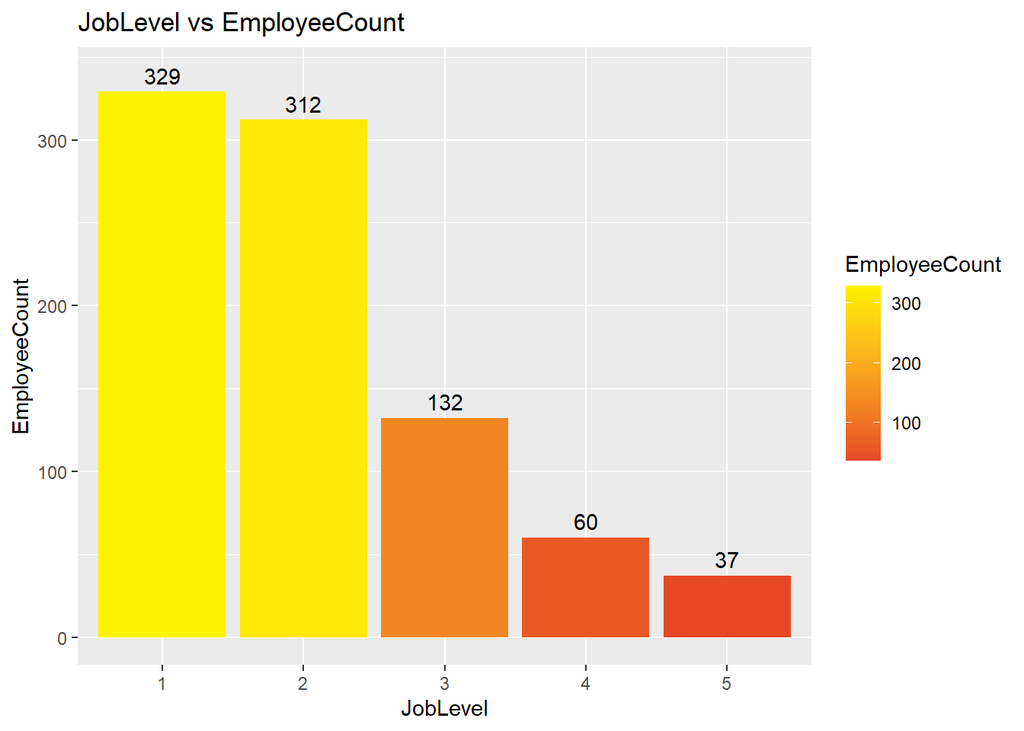

```r
ggplot(data=JobLeveldf,aes(x=JobLevel,y = EmployeeCount, fill = EmployeeCount ))+ geom_bar(stat ="identity")+ggtitle("JobLevel vs EmployeeCount") + scale_fill_gradient2(low= '#971B1E', mid = '#E02124', high = '#FFF200', space='#E1E1E1') + geom_text(aes(x= JobLevel, EmployeeCount +10, label = EmployeeCount, fill = NULL), data = JobLeveldf)
```

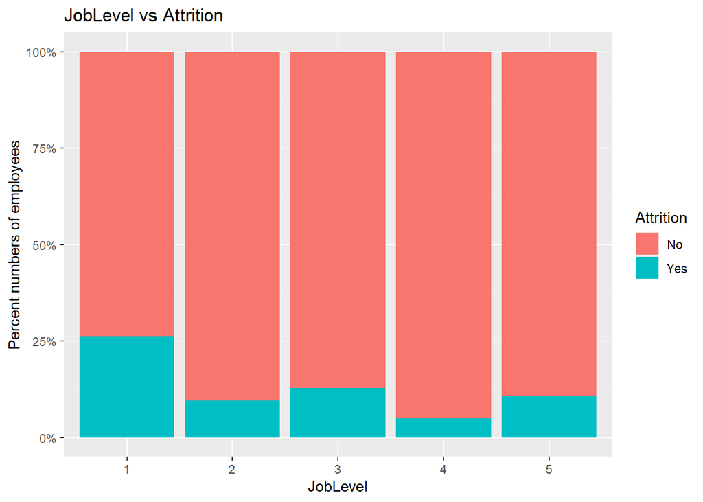

```r
ggplot(data, aes_string(x = "JobLevel", fill = "Attrition")) +
  geom_bar(position = "fill") +
  scale_y_continuous(labels = scales::percent) +
   xlab("JobLevel") + ylab("Percent numbers of employees") + ggtitle("JobLevel vs Attrition")
```

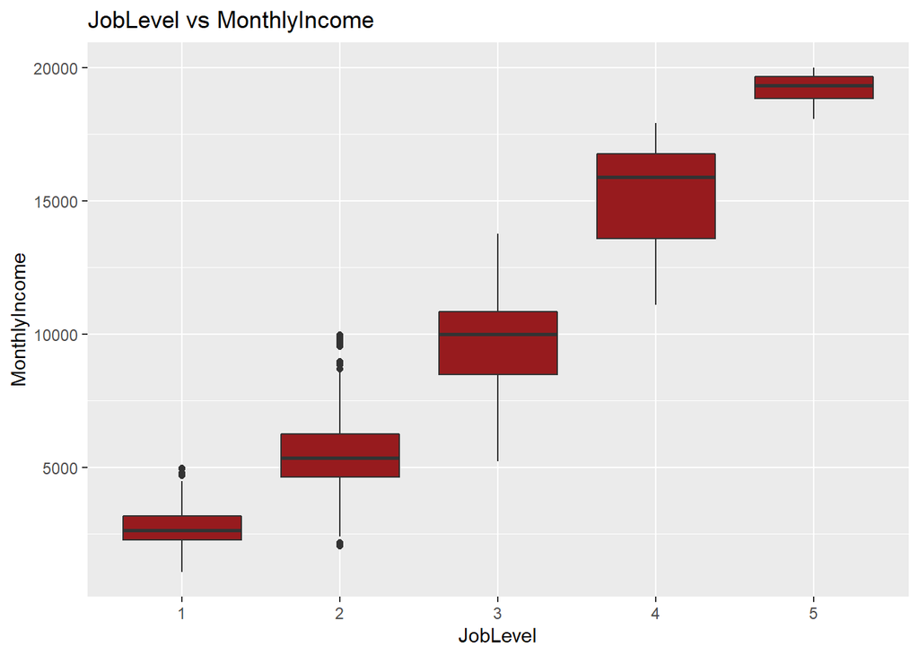

```r
ggplot(data,aes_string(x= "JobLevel" , y ="MonthlyIncome", fill ="JobLevel" ))+geom_boxplot(fill=c('#971B1E'))+ggtitle("JobLevel vs MonthlyIncome")
```

### JobRole . sales representative have higher attrition

```r
data$JobRole <- as.factor(data$JobRole)
JobRoledf <-data %>% group_by(JobRole) %>% summarise(EmployeeCount =n(), Proportion = scales::percent(n()/dim(data)[1]))
JobRoledf
```

```
## # A tibble: 9 x 3
##   JobRole                   EmployeeCount Proportion
##   <fct>                             <int> <chr>
## 1 Healthcare Representative            76 9%
## 2 Human Resources                      27 3%
## 3 Laboratory Technician               153 18%
## 4 Manager                              51 6%
## 5 Manufacturing Director               87 10%
## 6 Research Director                    51 6%
## 7 Research Scientist                  172 20%
## 8 Sales Executive                     200 23%
## 9 Sales Representative                 53 6%
```

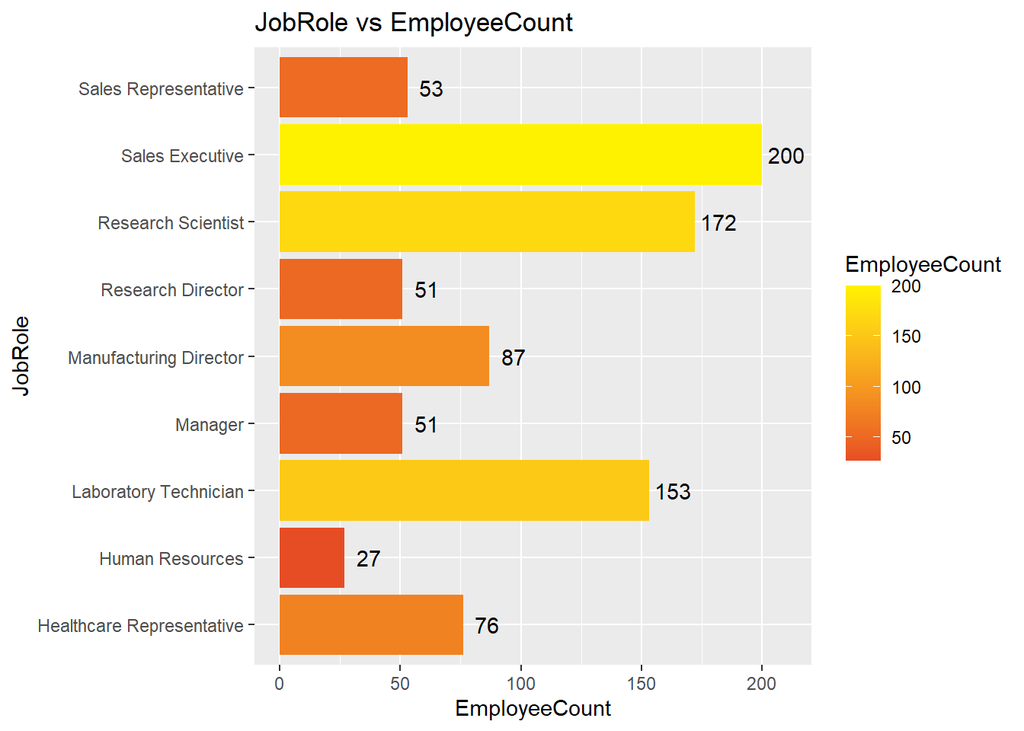

```r
ggplot(data=JobRoledf,aes(x=JobRole,y = EmployeeCount, fill = EmployeeCount ))+ geom_bar(stat ="identity")+ggtitle("JobRole vs EmployeeCount") + scale_fill_gradient2(low= '#971B1E', mid = '#E02124', high = '#FFF200', space='#E1E1E1')+ coord_flip()+ geom_text(aes(x= JobRole, EmployeeCount +10, label = EmployeeCount, fill = NULL), data = JobRoledf)
```

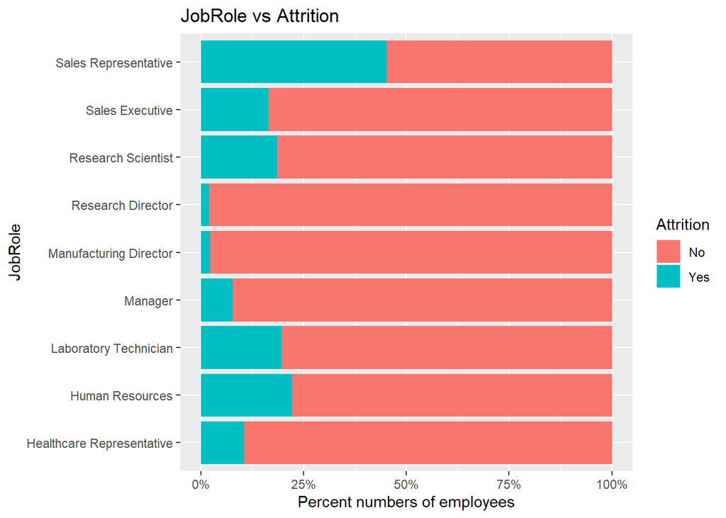

```r
ggplot(data, aes_string(x = "JobRole", fill = "Attrition")) +
  geom_bar(position = "fill") +
  scale_y_continuous(labels = scales::percent) +
   xlab("JobRole") + ylab("Percent numbers of employees") + ggtitle("JobRole vs Attrition")+coord_flip()
```

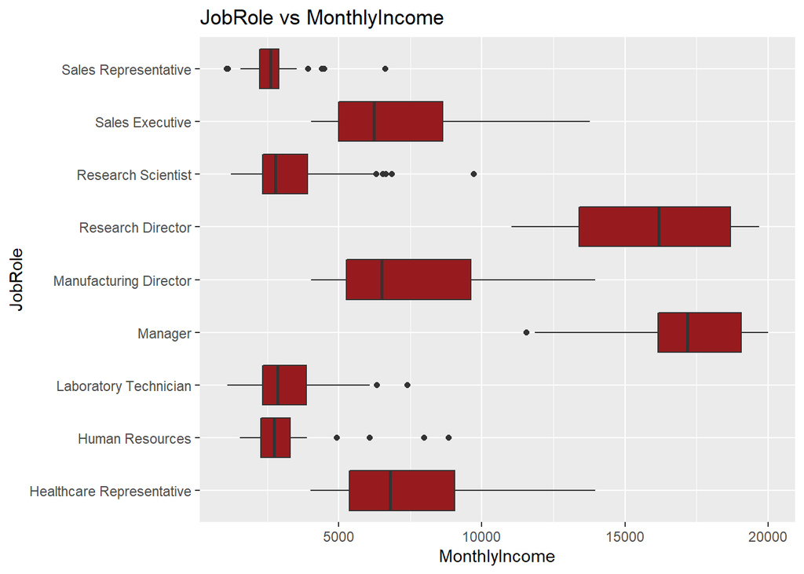

```r
ggplot(data,aes_string(x= "JobRole" , y ="MonthlyIncome", fill ="JobRole" ))+geom_boxplot(fill=c('#971B1E'))+ggtitle("JobRole vs MonthlyIncome")+coord_flip()
```

#### JobSatisfaction.Most of the people are satisfied with their jobs. Low satisfaction lead to higher rates in Attrition

```r
data$JobSatisfaction <- as.factor(data$JobSatisfaction)
JobSatisfactiondf <-data %>% group_by(JobSatisfaction) %>% summarise(EmployeeCount =n(), Proportion = scales::percent(n()/dim(data)[1]))
JobSatisfactiondf
```

```
## # A tibble: 4 x 3
##   JobSatisfaction EmployeeCount Proportion
##   <fct>                   <int> <chr>
## 1 1                         179 21%
## 2 2                         166 19%
## 3 3                         254 29%
## 4 4                         271 31%
```

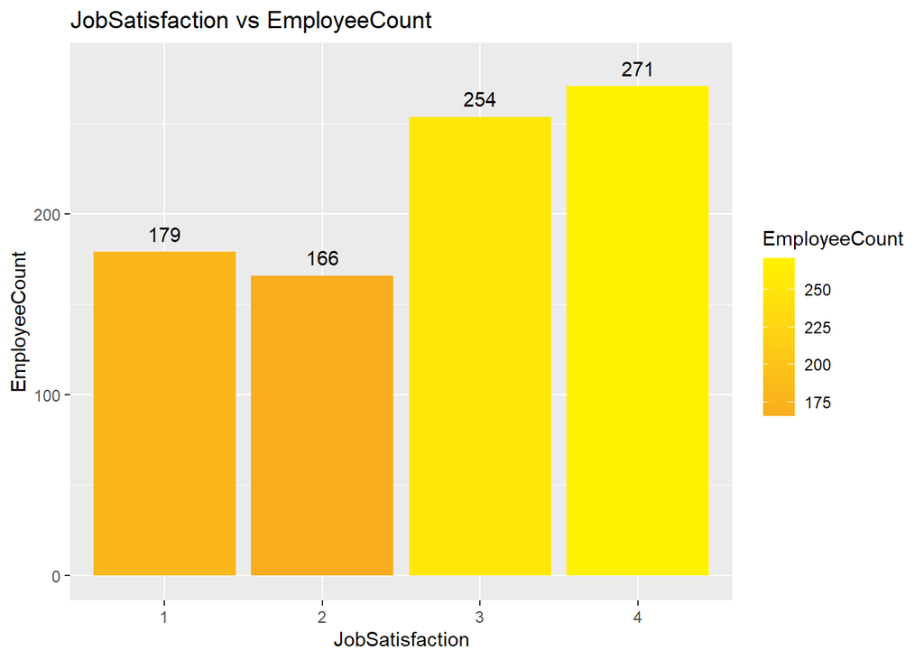

```r
ggplot(data=JobSatisfactiondf,aes(x=JobSatisfaction,y = EmployeeCount, fill = EmployeeCount ))+ geom_bar(stat ="identity")+ggtitle("JobSatisfaction vs EmployeeCount") + scale_fill_gradient2(low= '#971B1E', mid = '#E02124', high = '#FFF200', space='#E1E1E1')+ geom_text(aes(x= JobSatisfaction, EmployeeCount +10, label = EmployeeCount, fill = NULL), data = JobSatisfactiondf)
```

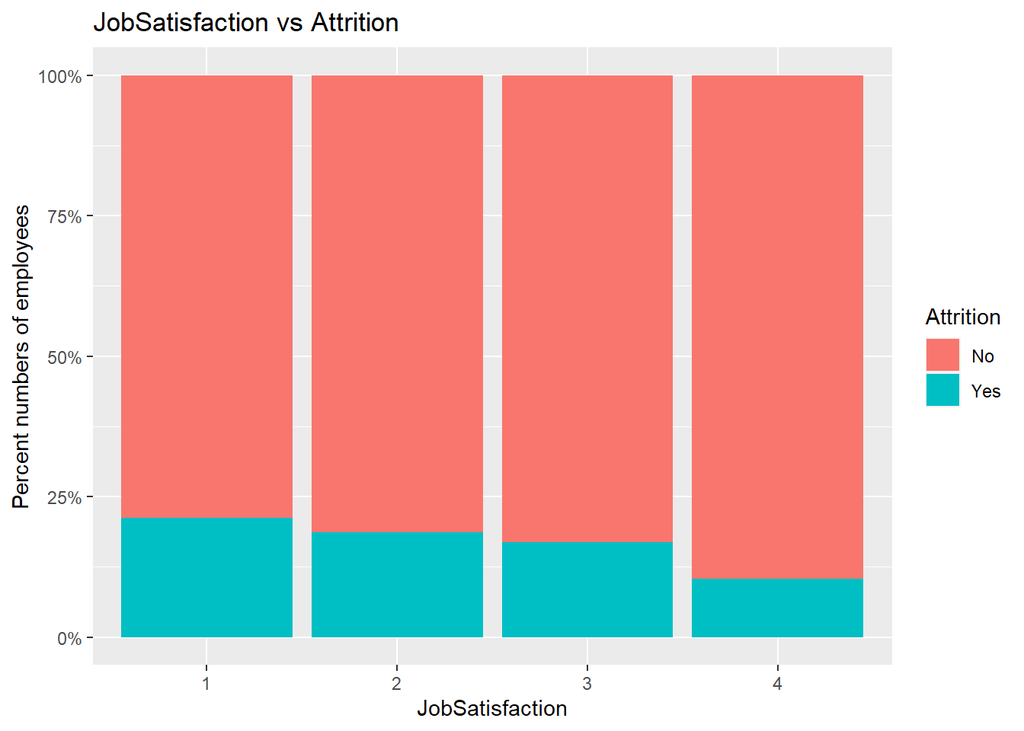

```r
ggplot(data, aes_string(x = "JobSatisfaction", fill = "Attrition")) +
  geom_bar(position = "fill") +
  scale_y_continuous(labels = scales::percent) +
 xlab("JobSatisfaction") + ylab("Percent numbers of employees") + ggtitle("JobSatisfaction vs Attrition")
```

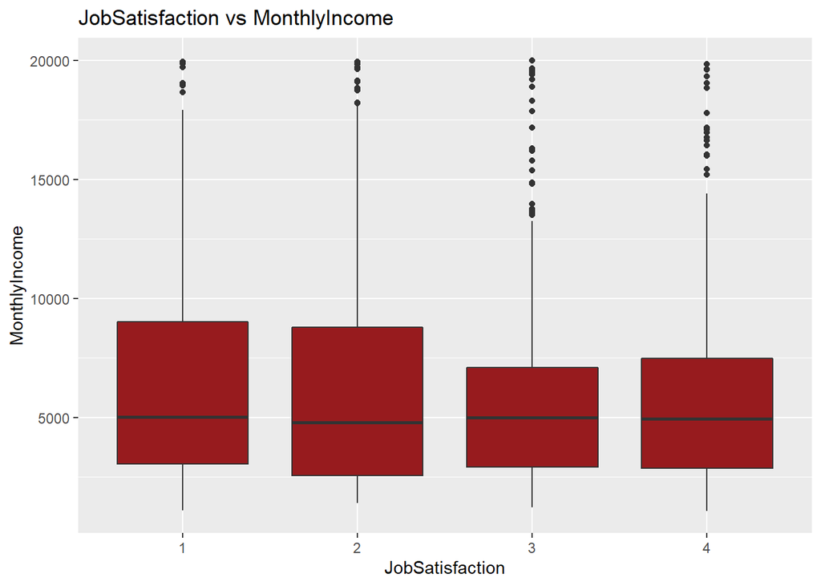

```r
ggplot(data,aes_string(x= "JobSatisfaction" , y ="MonthlyIncome", fill ="JobSatisfaction" ))+geom_boxplot(fill=c('#971B1E'))+ggtitle("JobSatisfaction vs MonthlyIncome")
```

####MaritalStatus. Most employees are married and single employee has higher attrition and have below average pay (box plot).

```r
data$MaritalStatus <- as.factor(data$MaritalStatus)
MaritalStatusdf <-data %>% group_by(MaritalStatus) %>% summarise(EmployeeCount =n(), Proportion = scales::percent(n()/dim(data)[1]))
MaritalStatusdf
```

```
## # A tibble: 3 x 3
##   MaritalStatus EmployeeCount Proportion
##   <fct>                 <int> <chr>
## 1 Divorced                191 22%
## 2 Married                 410 47%
## 3 Single                  269 31%
```

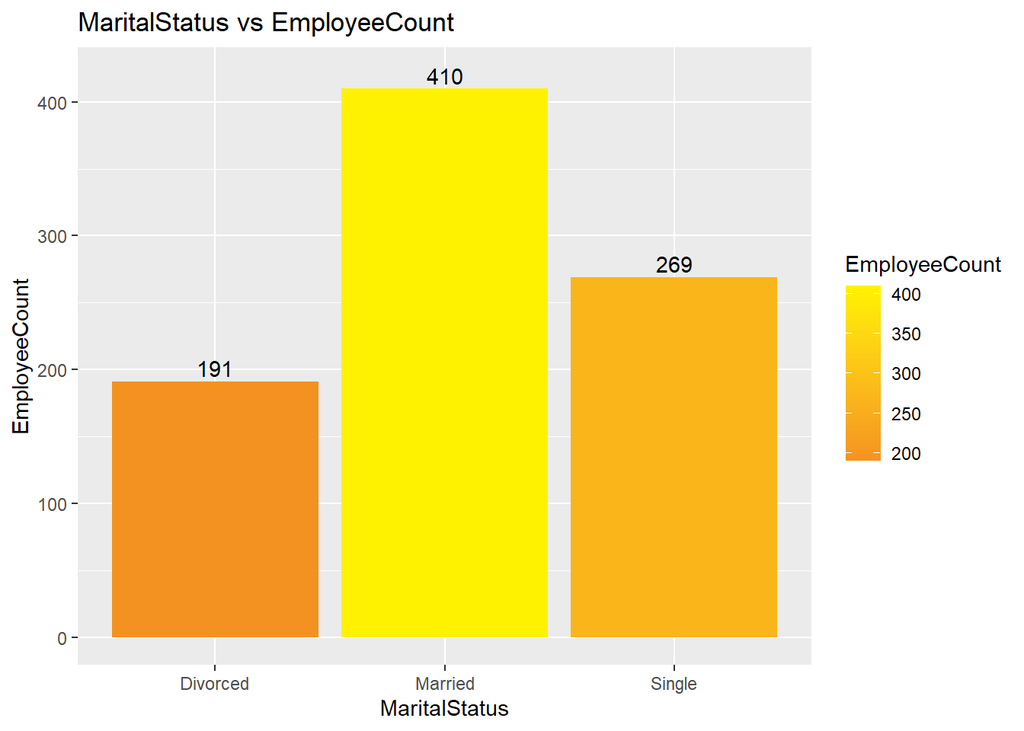

```r
ggplot(data=MaritalStatusdf,aes(x=MaritalStatus,y = EmployeeCount, fill = EmployeeCount ))+ geom_bar(stat ="identity")+ggtitle("MaritalStatus vs EmployeeCount") + scale_fill_gradient2(low= '#971B1E', mid = '#E02124', high = '#FFF200', space='#E1E1E1')+ geom_text(aes(x= MaritalStatus, EmployeeCount +10, label = EmployeeCount, fill = NULL), data = MaritalStatusdf)
```

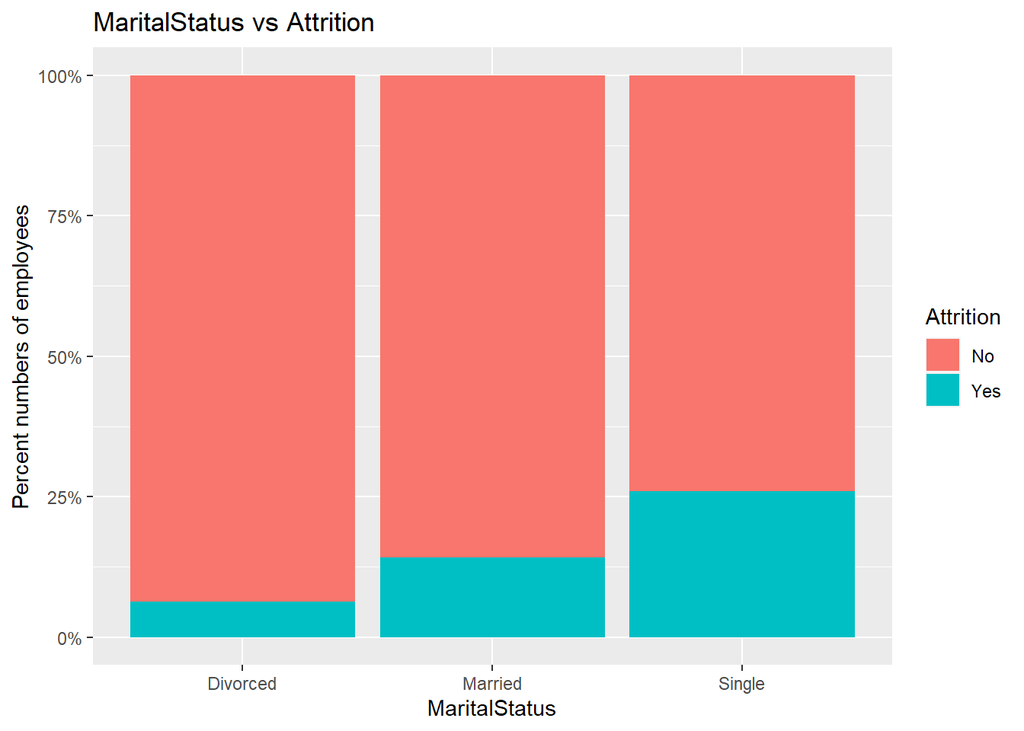

```r
ggplot(data, aes_string(x = "MaritalStatus", fill = "Attrition")) +
  geom_bar(position = "fill") +
  scale_y_continuous(labels = scales::percent) +
 xlab("MaritalStatus") + ylab("Percent numbers of employees") + ggtitle("MaritalStatus vs Attrition")
```

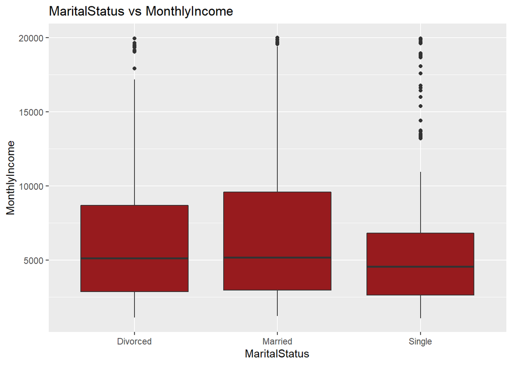

```r
ggplot(data,aes_string(x= "MaritalStatus" , y ="MonthlyIncome", fill ="MaritalStatus" ))+geom_boxplot(fill=c('#971B1E'))+ggtitle("MaritalStatus vs MonthlyIncome")
```

###NumCompaniesWorked

```r
data$NumCompaniesWorked <- as.factor(data$NumCompaniesWorked)
NumCompaniesWorkeddf <-data %>% group_by(NumCompaniesWorked) %>% summarise(EmployeeCount =n(), Proportion = scales::percent(n()/dim(data)[1]))
NumCompaniesWorkeddf
```

```
## # A tibble: 10 x 3
##    NumCompaniesWorked EmployeeCount Proportion
##    <fct>                      <int> <chr>
##  1 0                            111 13%
##  2 1                            320 37%
##  3 2                             74 9%
##  4 3                             91 10%
##  5 4                             85 10%
##  6 5                             43 5%
##  7 6                             39 4%
##  8 7                             46 5%
##  9 8                             28 3%
## 10 9                             33 4%
```

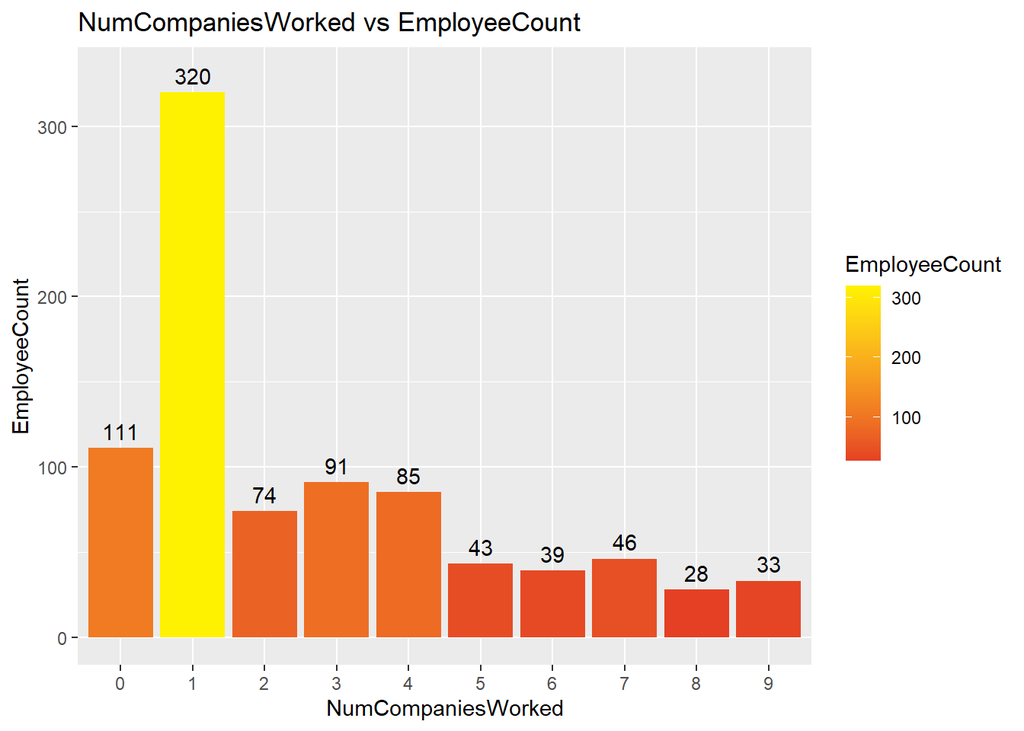

```r
ggplot(data=NumCompaniesWorkeddf,aes(x=NumCompaniesWorked,y = EmployeeCount, fill = EmployeeCount ))+ geom_bar(stat ="identity")+ggtitle("NumCompaniesWorked vs EmployeeCount") + scale_fill_gradient2(low= '#971B1E', mid = '#E02124', high = '#FFF200', space='#E1E1E1') + geom_text(aes(x= NumCompaniesWorked, EmployeeCount +10, label = EmployeeCount, fill = NULL), data = NumCompaniesWorkeddf)
```

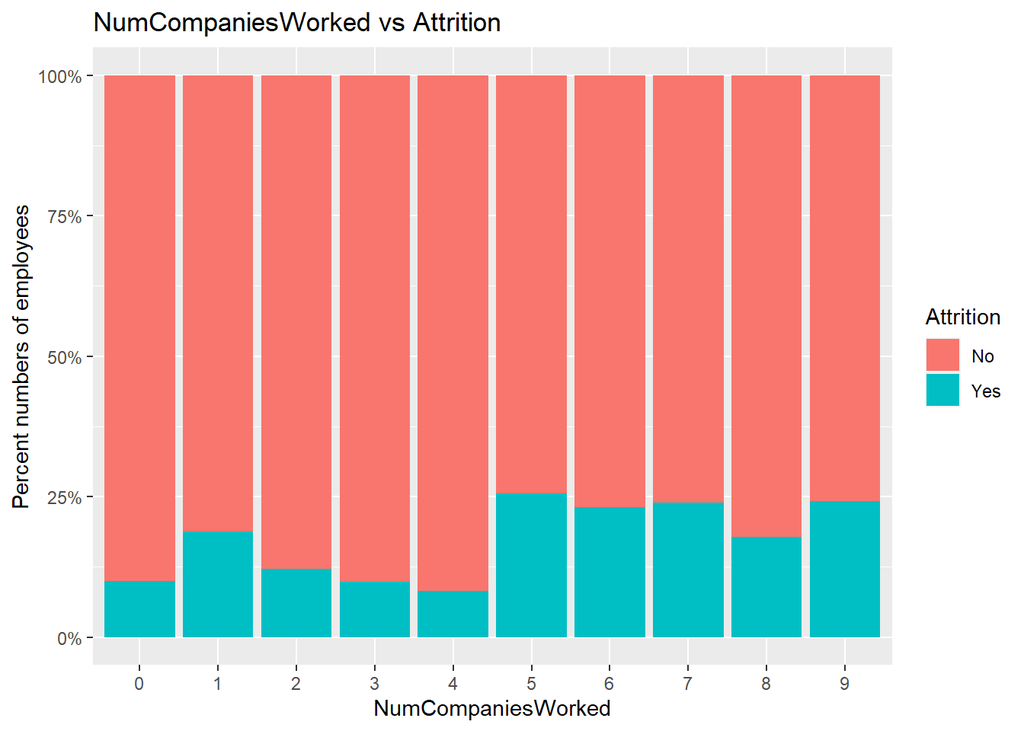

```r
ggplot(data, aes_string(x = "NumCompaniesWorked", fill = "Attrition")) +
  geom_bar(position = "fill") +
  scale_y_continuous(labels = scales::percent) +
   xlab("NumCompaniesWorked") + ylab("Percent numbers of employees") + ggtitle("NumCompaniesWorked vs Attrition")
```

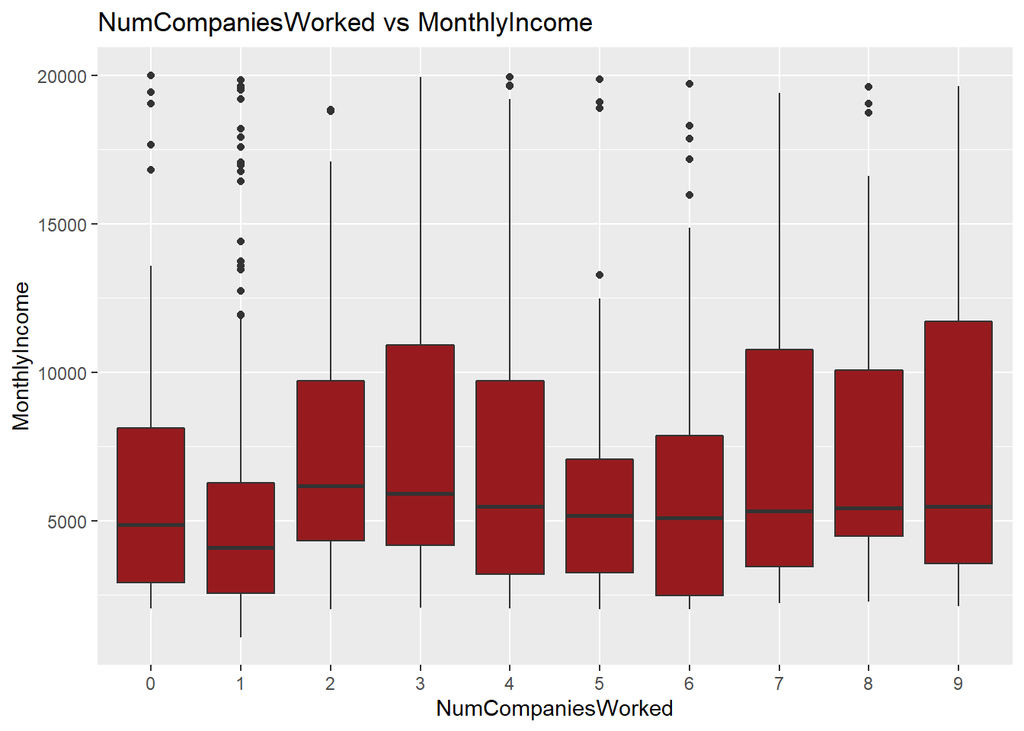

```r
ggplot(data,aes_string(x= "NumCompaniesWorked" , y ="MonthlyIncome", fill ="NumCompaniesWorked" ))+geom_boxplot(fill=c('#971B1E'))+ggtitle("NumCompaniesWorked vs MonthlyIncome")
```

###OverTime

```r
data$OverTime <- as.factor(data$OverTime)
OverTimedf <-data %>% group_by(OverTime) %>% summarise(EmployeeCount =n(), Proportion = scales::percent(n()/dim(data)[1]))
OverTimedf
```

```
## # A tibble: 2 x 3
##   OverTime EmployeeCount Proportion
##   <fct>            <int> <chr>
## 1 No                 618 71%
## 2 Yes                252 29%
```

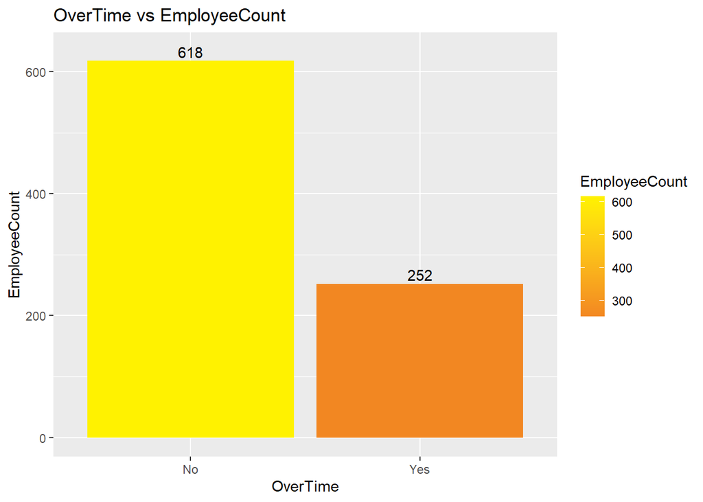

```r
ggplot(data=OverTimedf,aes(x=OverTime,y = EmployeeCount, fill = EmployeeCount ))+ geom_bar(stat ="identity")+ggtitle("OverTime vs EmployeeCount") + scale_fill_gradient2(low= '#971B1E', mid = '#E02124', high = '#FFF200', space='#E1E1E1') + geom_text(aes(x= OverTime, EmployeeCount +15, label = EmployeeCount, fill = NULL), data = OverTimedf)
```

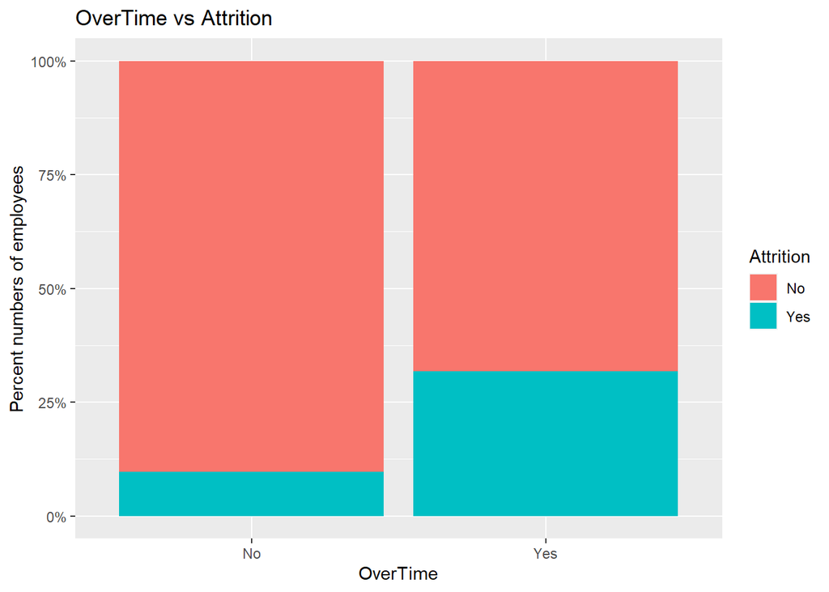

```r
ggplot(data, aes_string(x = "OverTime", fill = "Attrition")) +
  geom_bar(position = "fill") +
  scale_y_continuous(labels = scales::percent) +
   xlab("OverTime") + ylab("Percent numbers of employees") + ggtitle("OverTime vs Attrition")
```

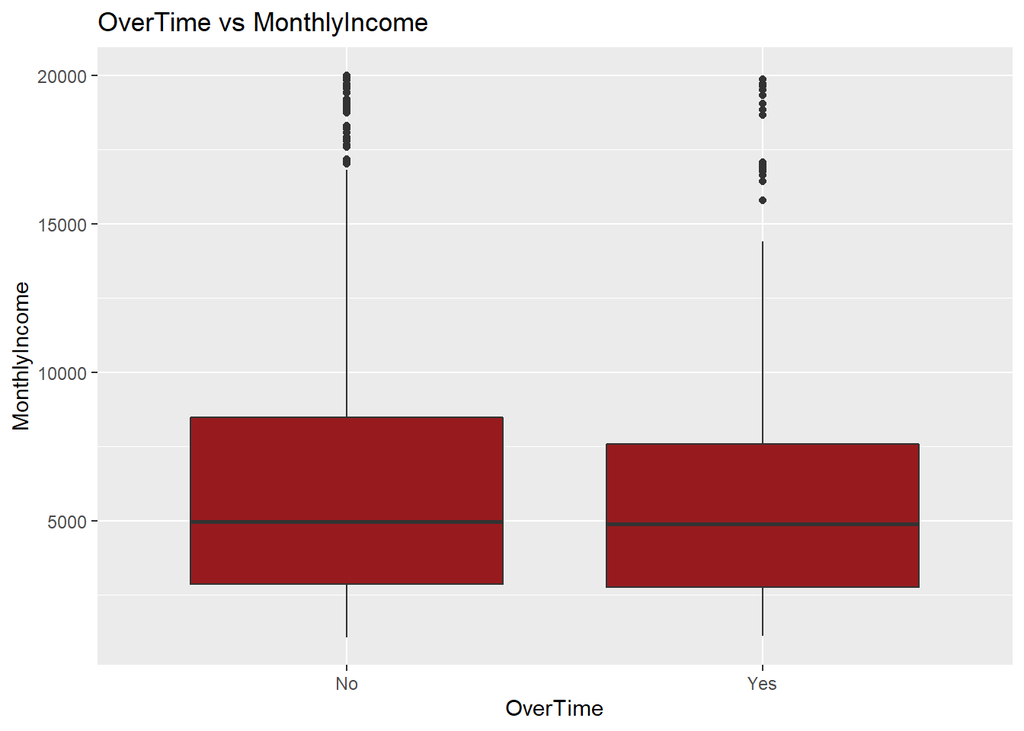

```r
ggplot(data,aes_string(x= "OverTime" , y ="MonthlyIncome", fill ="OverTime" ))+geom_boxplot(fill=c('#971B1E'))+ggtitle("OverTime vs MonthlyIncome")
```

###PercentSalaryHike/ Lower monthly income has higher salray hike have higher rate if attrition

```r
data$PercentSalaryHike <- as.factor(data$PercentSalaryHike)
PercentSalaryHikedf <-data %>% group_by(PercentSalaryHike) %>% summarise(EmployeeCount =n(), Proportion = scales::percent(n()/dim(data)[1]))
PercentSalaryHikedf
```

```
## # A tibble: 15 x 3
##    PercentSalaryHike EmployeeCount Proportion
##    <fct>                     <int> <chr>
##  1 11                          126 14%
##  2 12                          119 14%
##  3 13                          123 14%
##  4 14                          120 14%
##  5 15                           54 6%
##  6 16                           43 5%
##  7 17                           56 6%
##  8 18                           57 7%
##  9 19                           40 5%
## 10 20                           27 3%
## 11 21                           33 4%
## 12 22                           30 3%
## 13 23                           17 2%
## 14 24                           14 2%
## 15 25                           11 1%
```

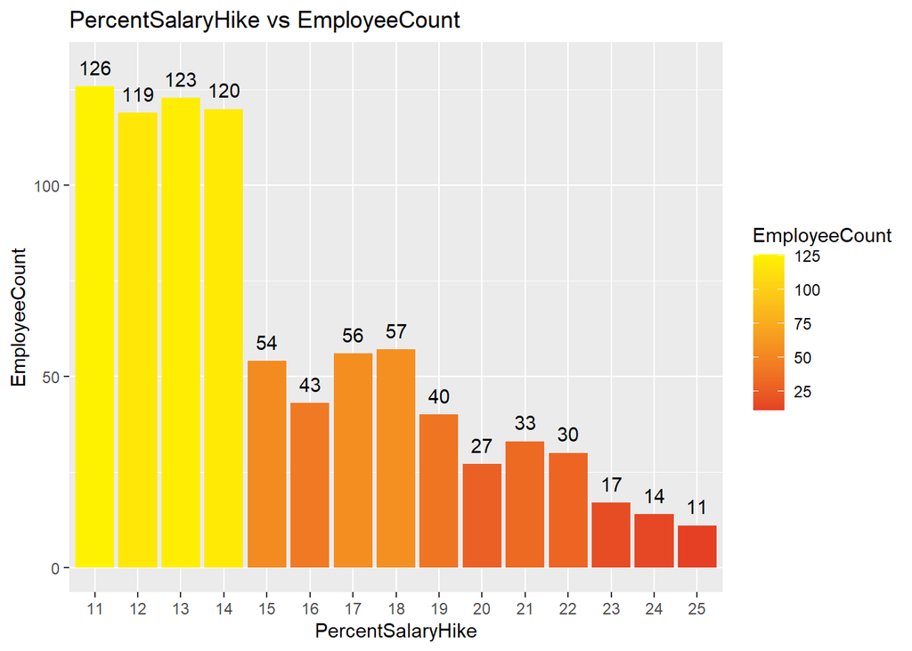

```r
ggplot(data=PercentSalaryHikedf,aes(x=PercentSalaryHike,y = EmployeeCount, fill = EmployeeCount ))+ geom_bar(stat ="identity")+ggtitle("PercentSalaryHike vs EmployeeCount") + scale_fill_gradient2(low= '#971B1E', mid = '#E02124', high = '#FFF200', space='#E1E1E1')+ geom_text(aes(x= PercentSalaryHike, EmployeeCount +5, label = EmployeeCount, fill = NULL), data = PercentSalaryHikedf)
```

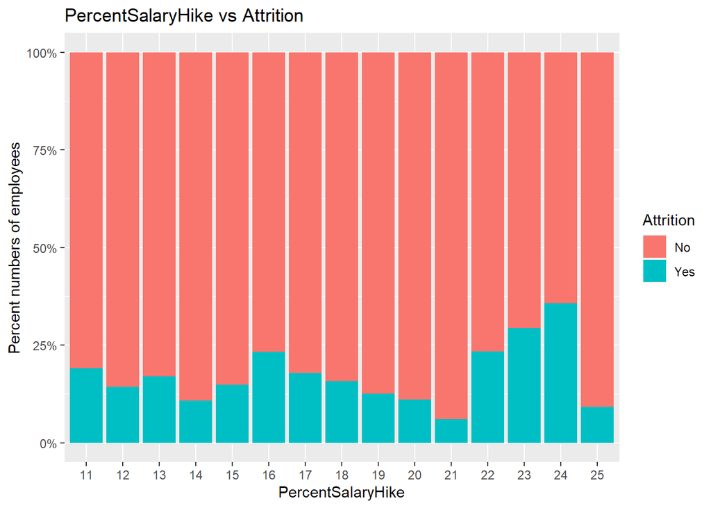

```r
ggplot(data, aes_string(x = "PercentSalaryHike", fill = "Attrition")) +
  geom_bar(position = "fill") +
  scale_y_continuous(labels = scales::percent) +
  xlab("PercentSalaryHike") + ylab("Percent numbers of employees") + ggtitle("PercentSalaryHike vs Attrition")
```

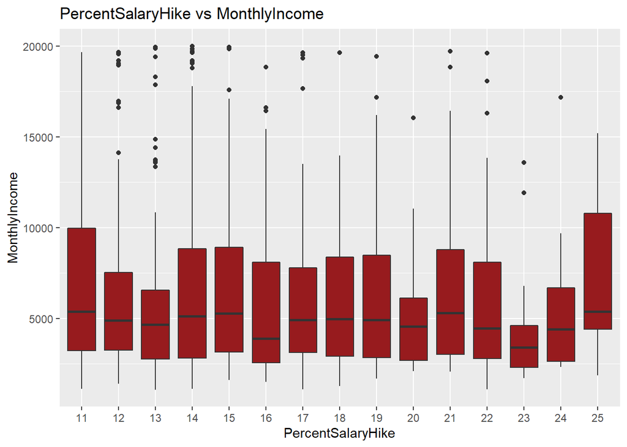

```r
ggplot(data,aes_string(x= "PercentSalaryHike" , y ="MonthlyIncome", fill ="PercentSalaryHike" ))+geom_boxplot(fill=c('#971B1E'))+ggtitle("PercentSalaryHike vs MonthlyIncome")
```

```r
data$PerformanceRating <- as.factor(data$PerformanceRating)
PerformanceRatingdf <-data %>% group_by(PerformanceRating) %>% summarise(EmployeeCount =n(), Proportion = scales::percent(n()/dim(data)[1]))
PerformanceRatingdf
```

```
## # A tibble: 2 x 3
##   PerformanceRating EmployeeCount Proportion
##   <fct>                     <int> <chr>
## 1 3                           738 85%
## 2 4                           132 15%
```

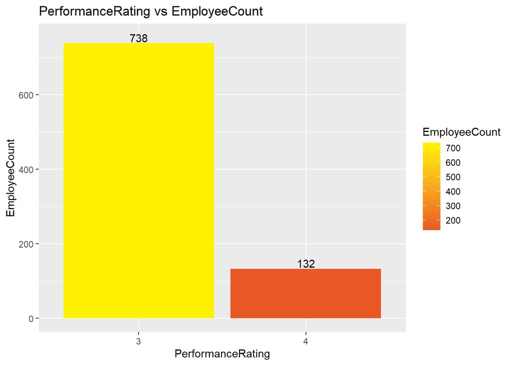

```r
ggplot(data=PerformanceRatingdf,aes(x=PerformanceRating,y = EmployeeCount, fill = EmployeeCount ))+ geom_bar(stat ="identity")+ggtitle("PerformanceRating vs EmployeeCount") + scale_fill_gradient2(low= '#971B1E', mid = '#E02124', high = '#FFF200', space='#E1E1E1') + geom_text(aes(x= PerformanceRating, EmployeeCount +15, label = EmployeeCount, fill = NULL), data = PerformanceRatingdf)
```

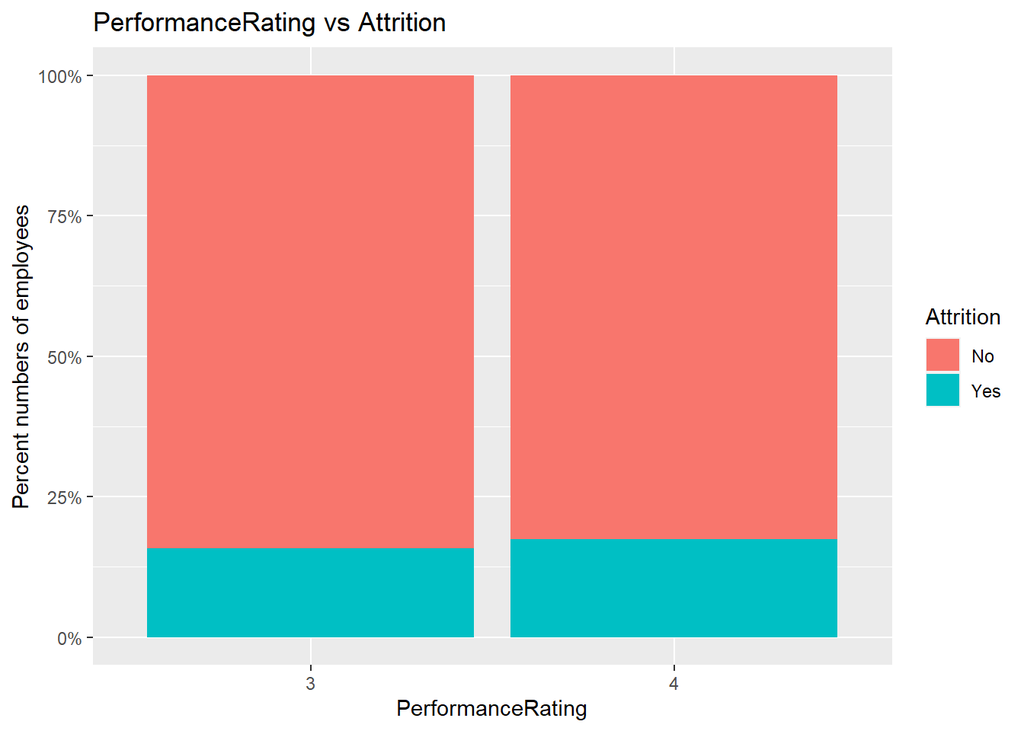

```r
ggplot(data, aes_string(x = "PerformanceRating", fill = "Attrition")) +
  geom_bar(position = "fill") +
  scale_y_continuous(labels = scales::percent) +
  xlab("PerformanceRating") + ylab("Percent numbers of employees") + ggtitle("PerformanceRating vs Attrition")
```

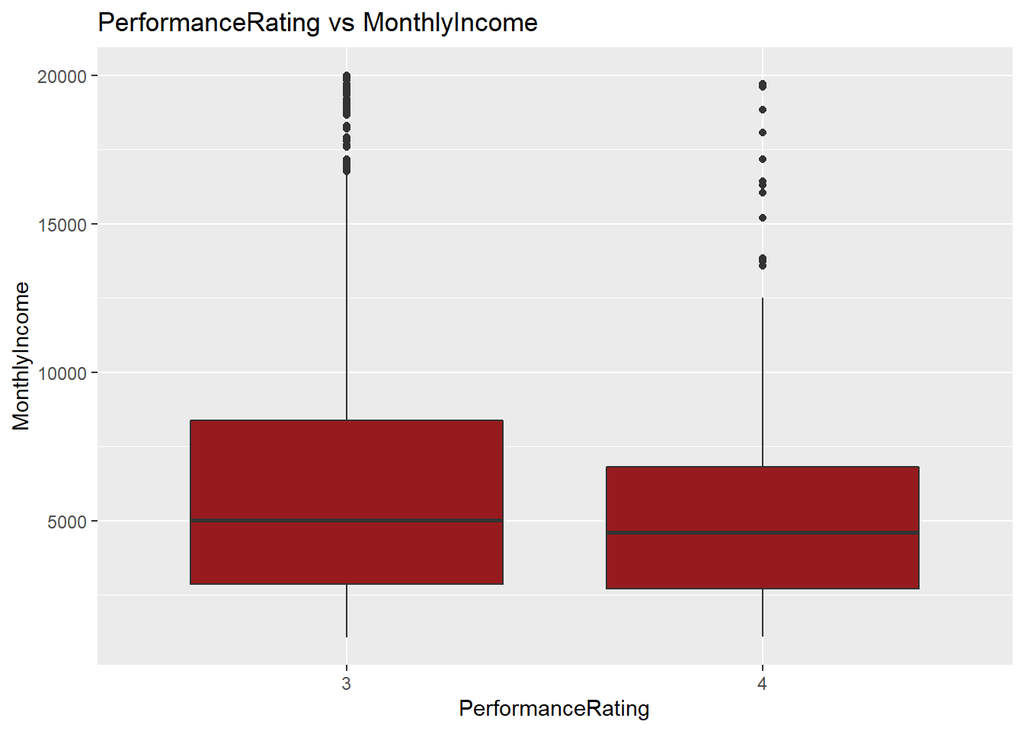

```r
ggplot(data,aes_string(x= "PerformanceRating" , y ="MonthlyIncome", fill ="PerformanceRating" ))+geom_boxplot(fill=c('#971B1E'))+ggtitle("PerformanceRating vs MonthlyIncome")
```

###RelationshipSatisfaction. Low relationship satisfaction has higher rate of attrition

```r
data$RelationshipSatisfaction <- as.factor(data$RelationshipSatisfaction)
RelationshipSatisfactiondf <-data %>% group_by(RelationshipSatisfaction) %>% summarise(EmployeeCount =n(), Proportion = scales::percent(n()/dim(data)[1]))
RelationshipSatisfactiondf
```

```
## # A tibble: 4 x 3
##   RelationshipSatisfaction EmployeeCount Proportion
##   <fct>                            <int> <chr>
## 1 1                                  174 20%
## 2 2                                  171 20%
## 3 3                                  261 30%
## 4 4                                  264 30%
```

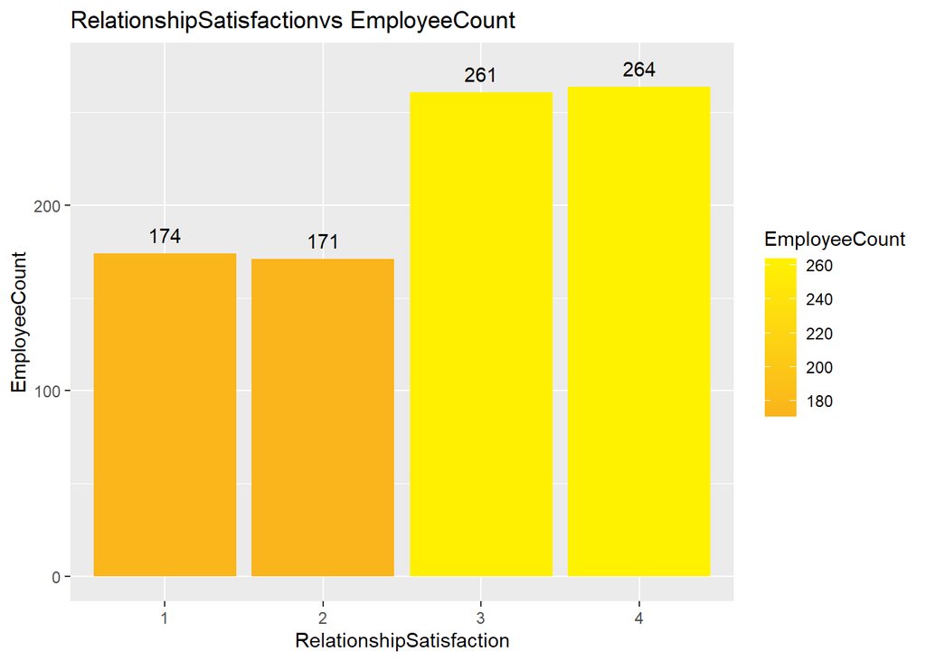

```r
ggplot(data=RelationshipSatisfactiondf,aes(x=RelationshipSatisfaction,y = EmployeeCount, fill = EmployeeCount ))+ geom_bar(stat ="identity")+ggtitle("RelationshipSatisfactionvs EmployeeCount") + scale_fill_gradient2(low= '#971B1E', mid = '#E02124', high = '#FFF200', space='#E1E1E1') + geom_text(aes(x= RelationshipSatisfaction, EmployeeCount +10, label = EmployeeCount, fill = NULL), data = RelationshipSatisfactiondf)
```

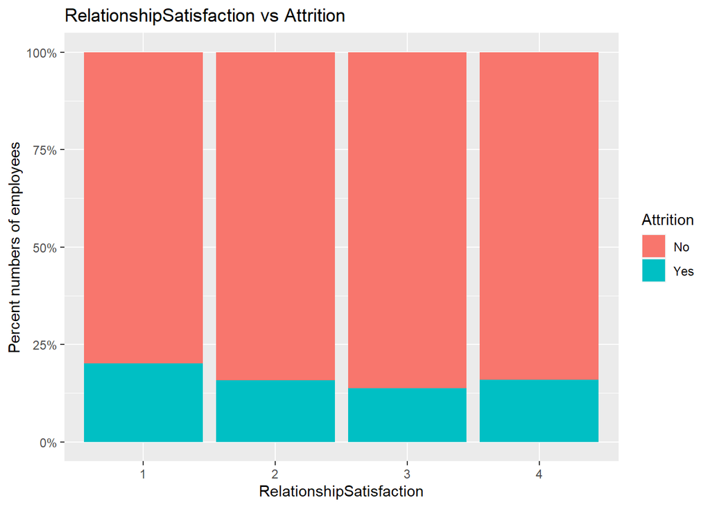

```r
ggplot(data, aes_string(x = "RelationshipSatisfaction", fill = "Attrition")) +
  geom_bar(position = "fill") +
  scale_y_continuous(labels = scales::percent) +
  xlab("RelationshipSatisfaction") + ylab("Percent numbers of employees") + ggtitle("RelationshipSatisfaction vs Attrition")
```

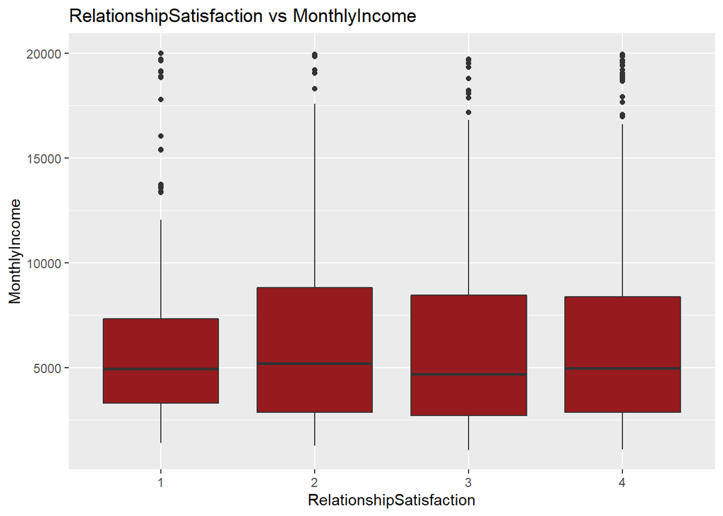

```r
ggplot(data,aes_string(x= "RelationshipSatisfaction" , y ="MonthlyIncome", fill ="RelationshipSatisfaction"  ))+geom_boxplot(fill=c('#971B1E'))+ggtitle("RelationshipSatisfaction vs MonthlyIncome")
```

###StockOptionLevel

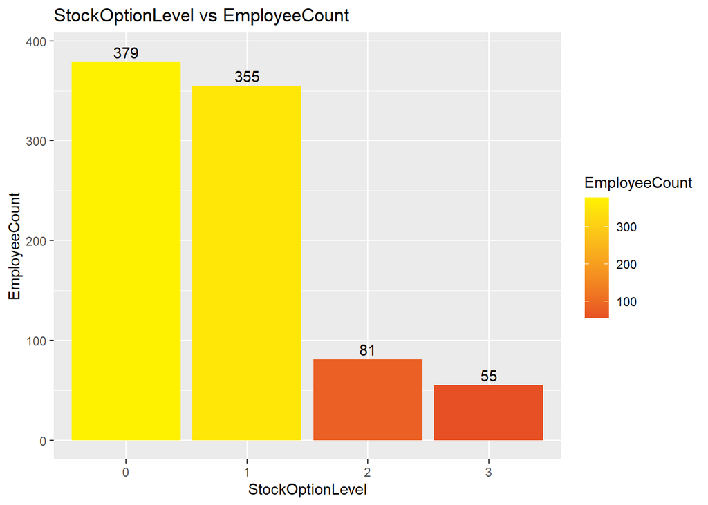

```r
data$StockOptionLevel <- as.factor(data$StockOptionLevel)
StockOptionLeveldf <-data %>% group_by(StockOptionLevel) %>% summarise(EmployeeCount =n(), Proportion = scales::percent(n()/dim(data)[1]))

ggplot(data=StockOptionLeveldf,aes(x=StockOptionLevel,y = EmployeeCount, fill = EmployeeCount ))+ geom_bar(stat ="identity")+ggtitle("StockOptionLevel vs EmployeeCount") + scale_fill_gradient2(low= '#971B1E', mid = '#E02124', high = '#FFF200', space='#E1E1E1')+ geom_text(aes(x= StockOptionLevel, EmployeeCount +10, label = EmployeeCount, fill = NULL), data = StockOptionLeveldf)
```

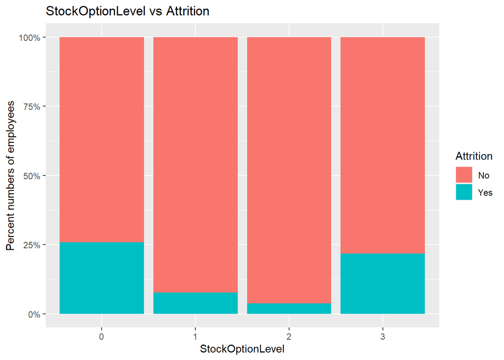

```r
ggplot(data, aes_string(x = "StockOptionLevel", fill = "Attrition")) +
  geom_bar(position = "fill") +
  scale_y_continuous(labels = scales::percent) +
   xlab("StockOptionLevel") + ylab("Percent numbers of employees") + ggtitle("StockOptionLevel vs Attrition")
```

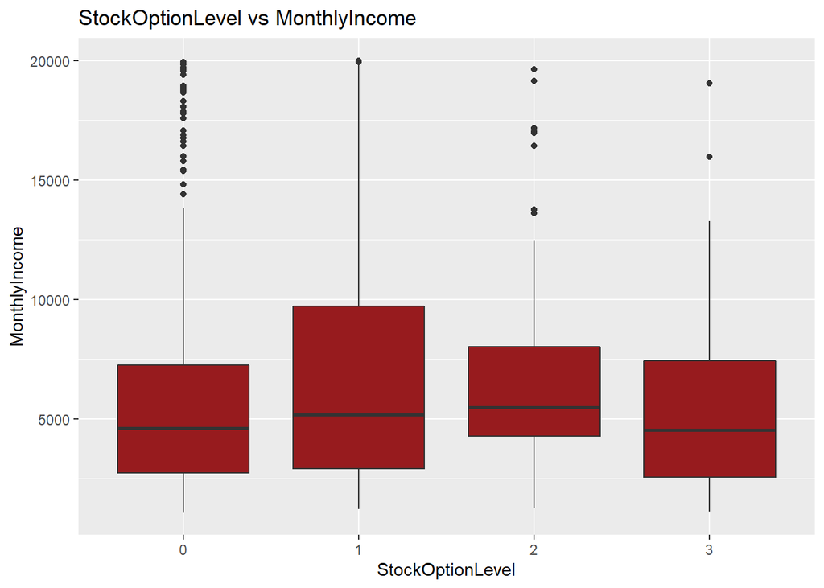

```r
ggplot(data,aes_string(x= "StockOptionLevel" , y ="MonthlyIncome", fill ="StockOptionLevel" ))+geom_boxplot(fill=c('#971B1E'))+ggtitle("StockOptionLevel vs MonthlyIncome")
```

###TotalWorkingYears. Income increases with working years. Employee after working 40 years are retiring and have higher rate of attrition. Most people tend to leave job at thier first year. 34-37 years employee are waiting for retirement possibly so no attrition.

```r
data$TotalWorkingYears <- as.factor(data$TotalWorkingYears)
TotalWorkingYearsdf <-data %>% group_by(TotalWorkingYears) %>% summarise(EmployeeCount =n(), Proportion = scales::percent(n()/dim(data)[1]))
TotalWorkingYearsdf
```

```
## # A tibble: 39 x 3
##    TotalWorkingYears EmployeeCount Proportion
##    <fct>                     <int> <chr>
##  1 0                             7 1%
##  2 1                            48 6%
##  3 2                            20 2%
##  4 3                            27 3%
##  5 4                            35 4%
##  6 5                            49 6%
##  7 6                            72 8%
##  8 7                            47 5%
##  9 8                            61 7%
## 10 9                            58 7%
## # ... with 29 more rows
```

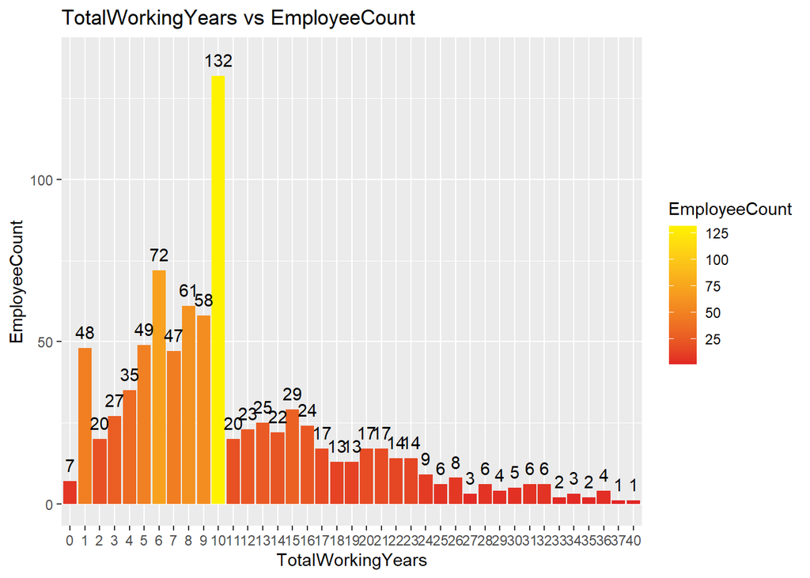

```r
ggplot(data=TotalWorkingYearsdf,aes(x=TotalWorkingYears,y = EmployeeCount, fill = EmployeeCount ))+ geom_bar(stat ="identity")+ggtitle("TotalWorkingYears vs EmployeeCount") + scale_fill_gradient2(low= '#971B1E', mid = '#E02124', high = '#FFF200', space='#E1E1E1') + geom_text(aes(x= TotalWorkingYears, EmployeeCount +5, label = EmployeeCount, fill = NULL), data = TotalWorkingYearsdf)
```

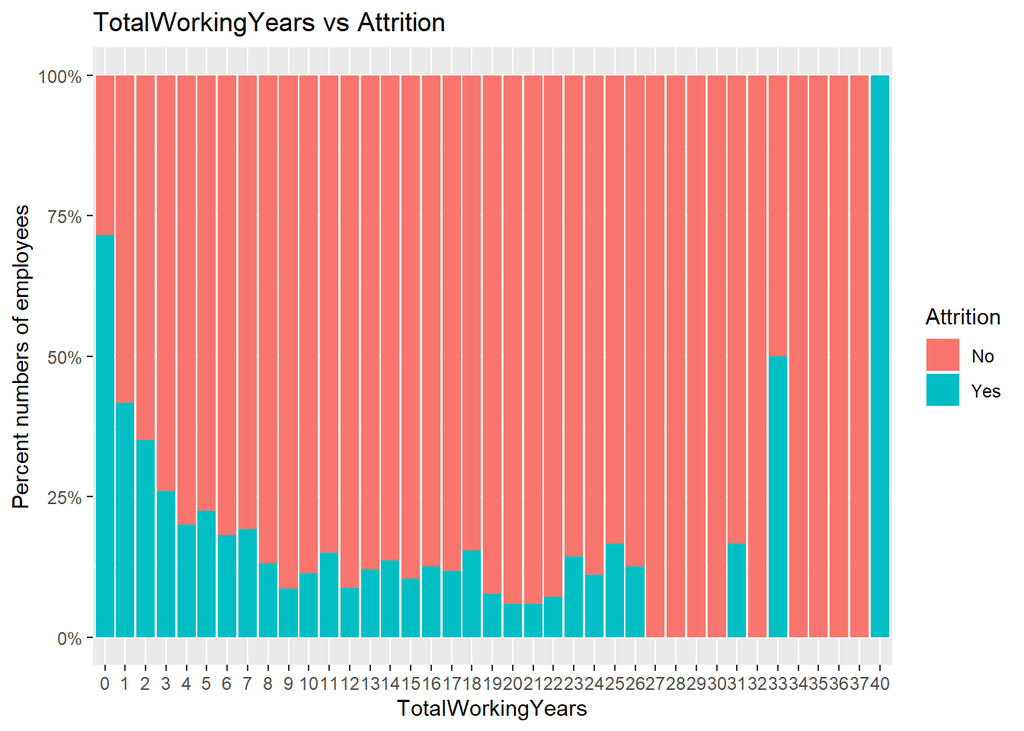

```r
ggplot(data, aes_string(x = "TotalWorkingYears", fill = "Attrition")) +
  geom_bar(position = "fill") +
  scale_y_continuous(labels = scales::percent) +
  xlab("TotalWorkingYears") + ylab("Percent numbers of employees") + ggtitle("TotalWorkingYears vs Attrition")
```

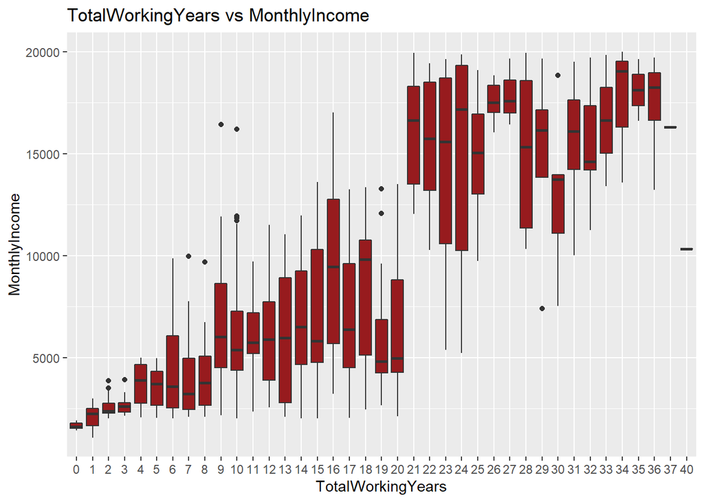

```r
ggplot(data,aes_string(x= "TotalWorkingYears" , y ="MonthlyIncome", fill ="TotalWorkingYears" ))+geom_boxplot(fill=c('#971B1E'))+ggtitle("TotalWorkingYears vs MonthlyIncome")
```

###TrainingTimesLastYear. Most employee get trained for 2-3 times a year. 0 and 4 has higher attrition rate.

```r
data$TrainingTimesLastYear <- as.factor(data$TrainingTimesLastYear)
TrainingTimesLastYeardf <-data %>% group_by(TrainingTimesLastYear) %>% summarise(EmployeeCount =n(), Proportion = scales::percent(n()/dim(data)[1]))
TrainingTimesLastYeardf
```

```
## # A tibble: 7 x 3
##   TrainingTimesLastYear EmployeeCount Proportion
##   <fct>                         <int> <chr>
## 1 0                                30 3%
## 2 1                                39 4%
## 3 2                               309 36%
## 4 3                               308 35%
## 5 4                                73 8%
## 6 5                                75 9%
## 7 6                                36 4%
```

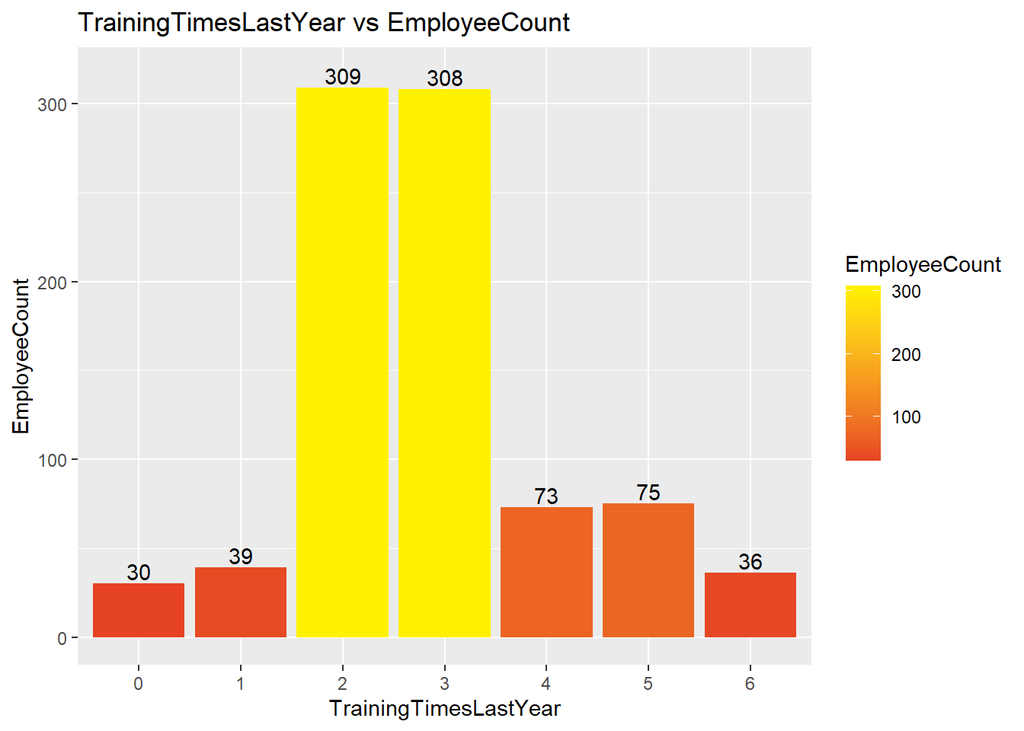

```r
ggplot(data=TrainingTimesLastYeardf,aes(x=TrainingTimesLastYear,y = EmployeeCount, fill = EmployeeCount ))+ geom_bar(stat ="identity")+ggtitle("TrainingTimesLastYear vs EmployeeCount") + scale_fill_gradient2(low= '#971B1E', mid = '#E02124', high = '#FFF200', space='#E1E1E1')+ geom_text(aes(x= TrainingTimesLastYear, EmployeeCount +7, label = EmployeeCount, fill = NULL), data = TrainingTimesLastYeardf)
```

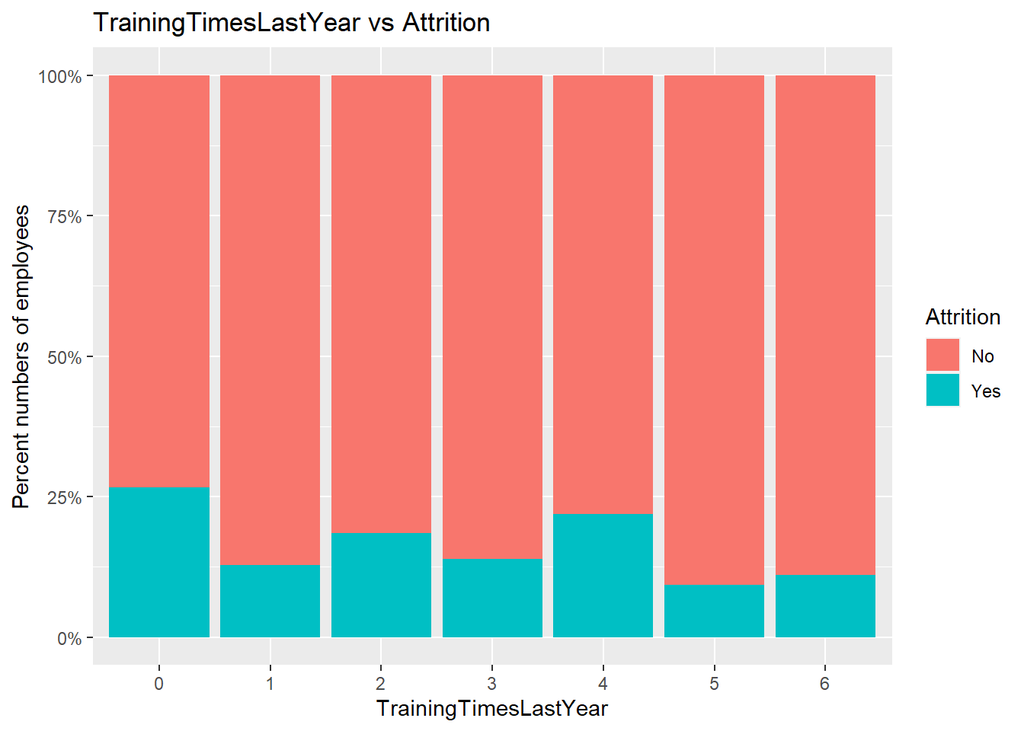

```r
ggplot(data, aes_string(x = "TrainingTimesLastYear", fill = "Attrition")) +
  geom_bar(position = "fill") +
  scale_y_continuous(labels = scales::percent) +
   xlab("TrainingTimesLastYear") + ylab("Percent numbers of employees") + ggtitle("TrainingTimesLastYear vs Attrition")
```

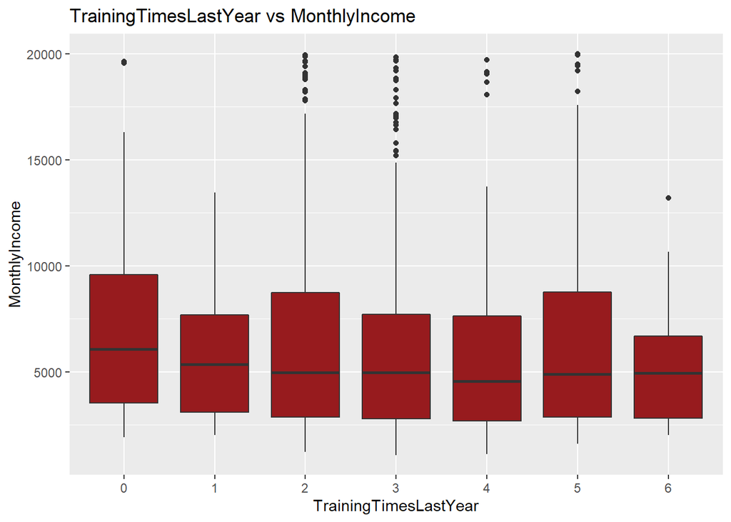

```r
ggplot(data,aes_string(x= "TrainingTimesLastYear" , y ="MonthlyIncome", fill ="TrainingTimesLastYear" ))+geom_boxplot(fill=c('#971B1E'))+ggtitle("TrainingTimesLastYear vs MonthlyIncome")
```

###WorkLifeBalance. less worklifebalance higher attrition

```r
data$WorkLifeBalance <- as.factor(data$WorkLifeBalance)
WorkLifeBalancedf <-data %>% group_by(WorkLifeBalance) %>% summarise(EmployeeCount =n(), Proportion = scales::percent(n()/dim(data)[1]))
WorkLifeBalancedf
```

```
## # A tibble: 4 x 3
##   WorkLifeBalance EmployeeCount Proportion
##   <fct>                   <int> <chr>
## 1 1                          48 6%
## 2 2                         192 22%
## 3 3                         532 61%
## 4 4                          98 11%
```

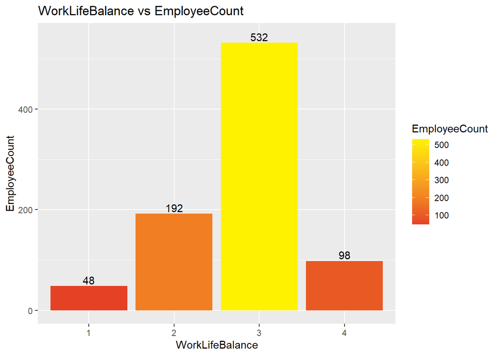

```r
ggplot(data=WorkLifeBalancedf,aes(x=WorkLifeBalance,y = EmployeeCount, fill = EmployeeCount ))+ geom_bar(stat ="identity")+ggtitle("WorkLifeBalance vs EmployeeCount") + scale_fill_gradient2(low= '#971B1E', mid = '#E02124', high = '#FFF200', space='#E1E1E1')+ geom_text(aes(x= WorkLifeBalance, EmployeeCount +12, label = EmployeeCount, fill = NULL), data = WorkLifeBalancedf)
```

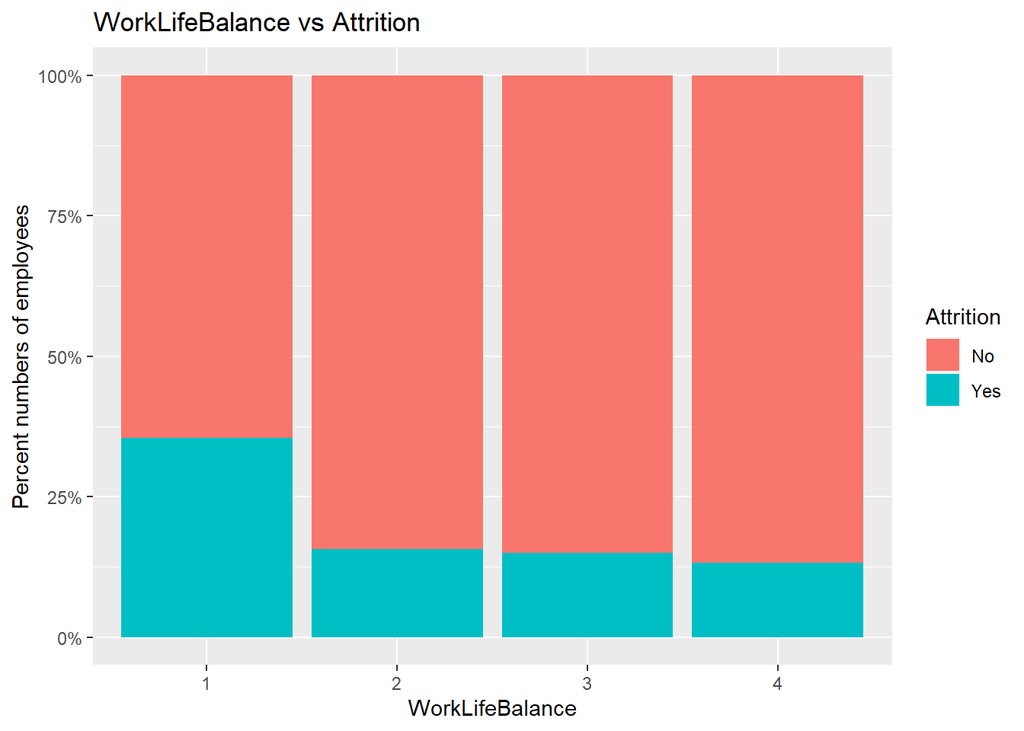

```r
ggplot(data, aes_string(x = "WorkLifeBalance", fill = "Attrition")) +
  geom_bar(position = "fill") +
  scale_y_continuous(labels = scales::percent) +
   xlab("WorkLifeBalance") + ylab("Percent numbers of employees") + ggtitle("WorkLifeBalance vs Attrition")
```

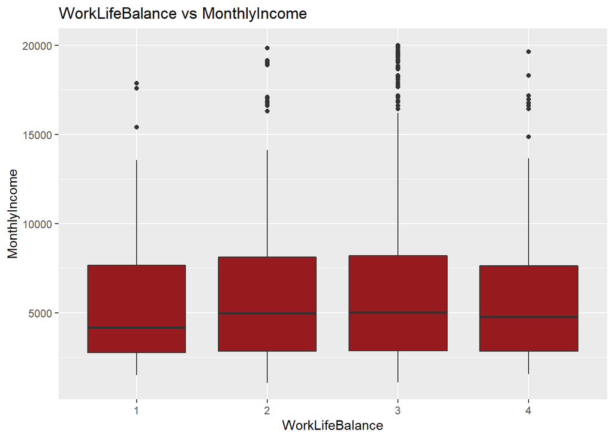

```r
ggplot(data,aes_string(x= "WorkLifeBalance" , y ="MonthlyIncome", fill ="WorkLifeBalance" ))+geom_boxplot(fill=c('#971B1E'))+ggtitle("WorkLifeBalance vs MonthlyIncome")
```

###YearsAtCompany. Income increases with time in company. New hires are likely to leave the company.

```r
data$YearsAtCompany <- as.factor(data$YearsAtCompany)
YearsAtCompanydf <-data %>% group_by(YearsAtCompany) %>% summarise(EmployeeCount =n(), Proportion = scales::percent(n()/dim(data)[1]))
YearsAtCompanydf
```

```
## # A tibble: 32 x 3
##    YearsAtCompany EmployeeCount Proportion
##    <fct>                  <int> <chr>
##  1 0                         28 3%
##  2 1                        107 12%
##  3 2                         77 9%
##  4 3                         85 10%
##  5 4                         54 6%
##  6 5                        105 12%
##  7 6                         44 5%
##  8 7                         42 5%
##  9 8                         50 6%
## 10 9                         52 6%
## # ... with 22 more rows
```

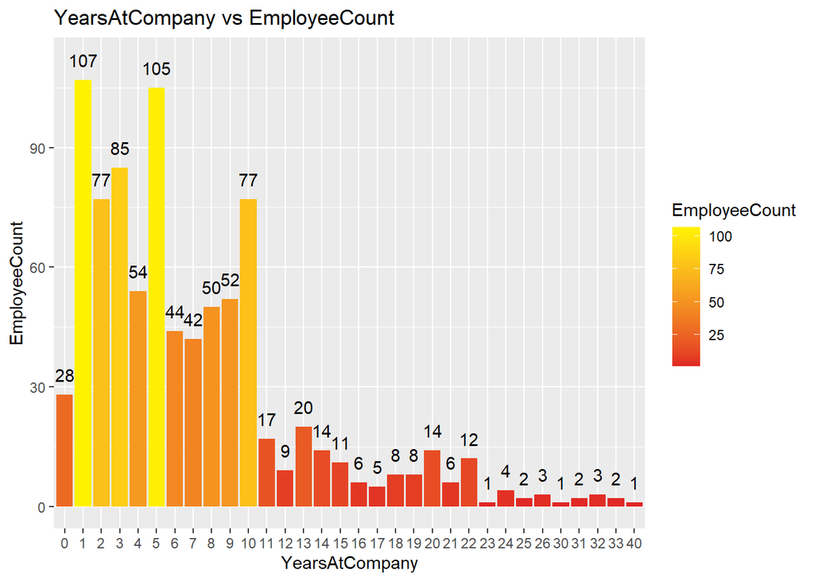

```r
ggplot(data=YearsAtCompanydf,aes(x=YearsAtCompany,y = EmployeeCount, fill = EmployeeCount ))+ geom_bar(stat ="identity")+ggtitle("YearsAtCompany vs EmployeeCount") + scale_fill_gradient2(low= '#971B1E', mid = '#E02124', high = '#FFF200', space='#E1E1E1') + geom_text(aes(x= YearsAtCompany, EmployeeCount +5, label = EmployeeCount, fill = NULL), data = YearsAtCompanydf)
```

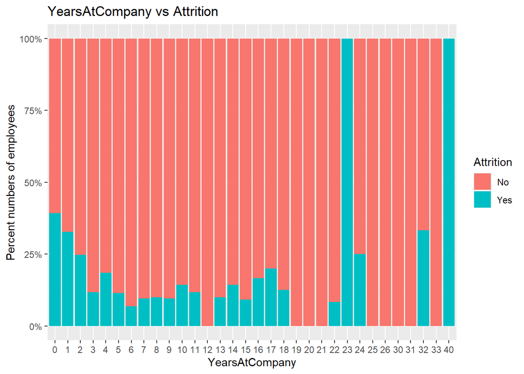

```r
ggplot(data, aes_string(x = "YearsAtCompany", fill = "Attrition")) +
  geom_bar(position = "fill") +
  scale_y_continuous(labels = scales::percent) +
   xlab("YearsAtCompany") + ylab("Percent numbers of employees") + ggtitle("YearsAtCompany vs Attrition")
```

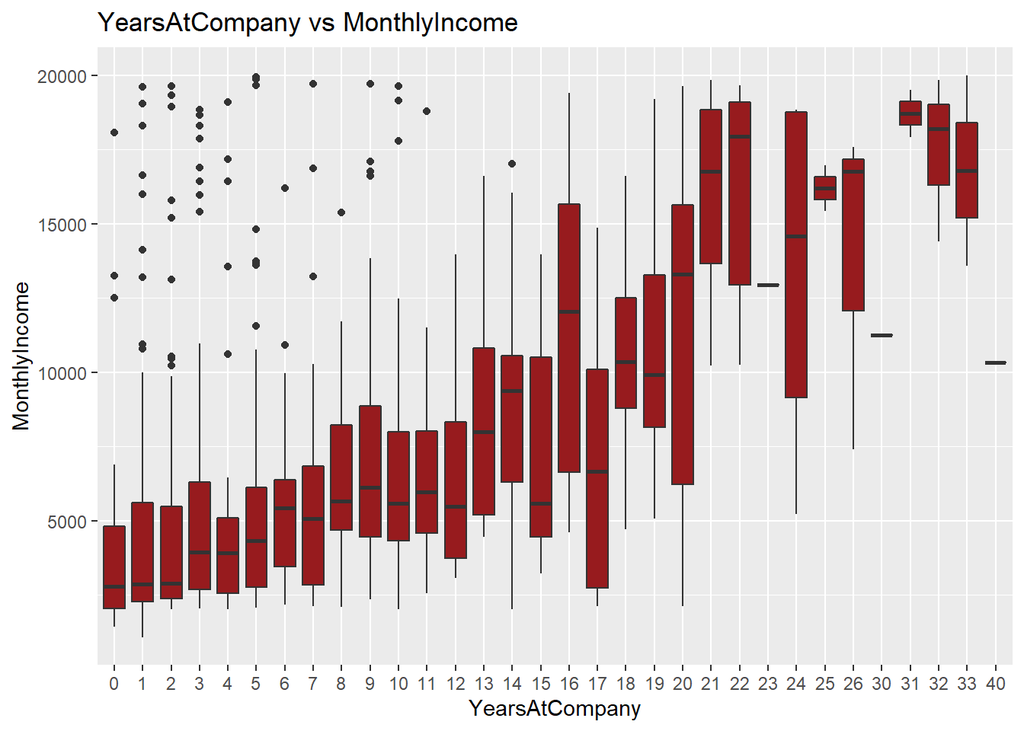

```r
ggplot(data,aes_string(x= "YearsAtCompany" , y ="MonthlyIncome", fill ="YearsAtCompany" ))+geom_boxplot(fill=c('#971B1E'))+ggtitle("YearsAtCompany vs MonthlyIncome")
```

###important ###YearsInCurrentRole. Employee staying in current role more than 15 years are less likely to leave the job.

```r
data$YearsInCurrentRole <- as.factor(data$YearsInCurrentRole)
YearsInCurrentRoledf <-data %>% group_by(YearsInCurrentRole) %>% summarise(EmployeeCount =n(), Proportion = scales::percent(n()/dim(data)[1]))
YearsInCurrentRoledf
```

```
## # A tibble: 19 x 3
##    YearsInCurrentRole EmployeeCount Proportion
##    <fct>                      <int> <chr>
##  1 0                            151 17%
##  2 1                             38 4%
##  3 2                            223 26%
##  4 3                             68 8%
##  5 4                             53 6%
##  6 5                             26 3%
##  7 6                             17 2%
##  8 7                            136 16%
##  9 8                             56 6%
## 10 9                             40 5%
## 11 10                            14 2%
## 12 11                            15 2%
## 13 12                             7 1%
## 14 13                             9 1%
## 15 14                             7 1%
## 16 15                             3 0%
## 17 16                             3 0%
## 18 17                             3 0%
## 19 18                             1 0%
```

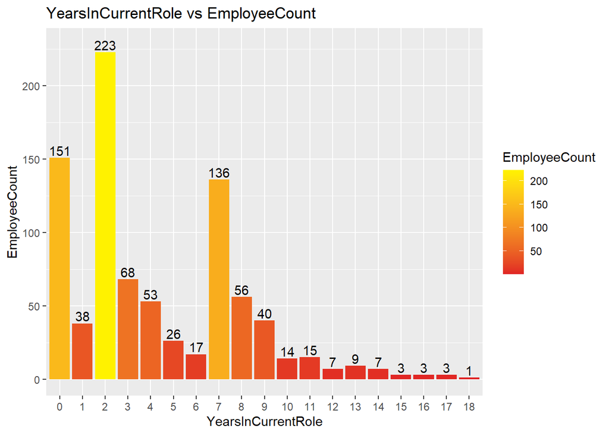

```r
ggplot(data=YearsInCurrentRoledf,aes(x=YearsInCurrentRole,y = EmployeeCount, fill = EmployeeCount ))+ geom_bar(stat ="identity")+ggtitle("YearsInCurrentRole vs EmployeeCount") + scale_fill_gradient2(low= '#971B1E', mid = '#E02124', high = '#FFF200', space='#E1E1E1') + geom_text(aes(x= YearsInCurrentRole, EmployeeCount +5, label = EmployeeCount, fill = NULL), data = YearsInCurrentRoledf)
```

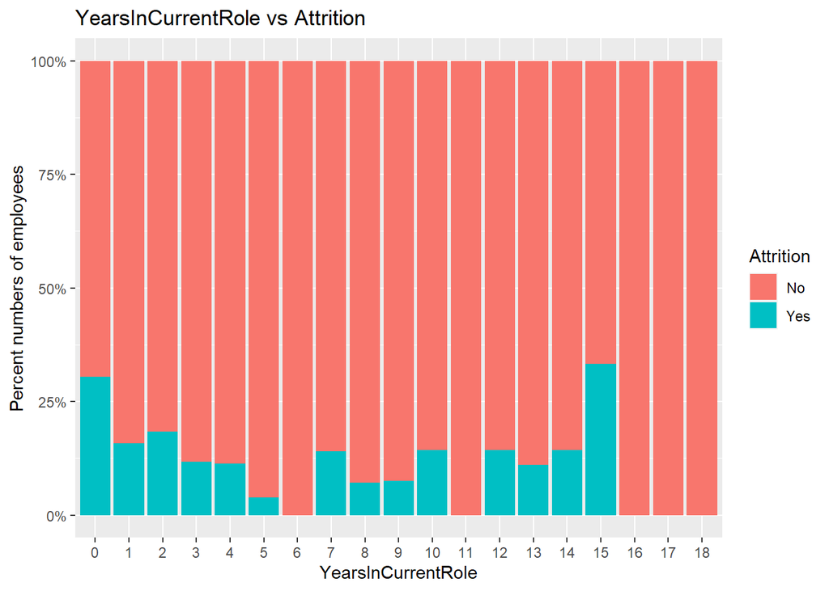

```r
ggplot(data, aes_string(x = "YearsInCurrentRole", fill = "Attrition")) +
  geom_bar(position = "fill") +
  scale_y_continuous(labels = scales::percent) +
   xlab("YearsInCurrentRole") + ylab("Percent numbers of employees") + ggtitle("YearsInCurrentRole vs Attrition")
```

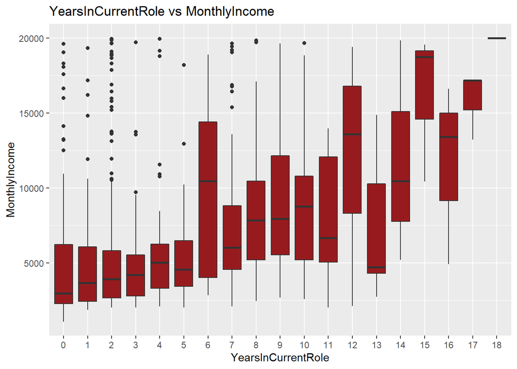

```r
ggplot(data,aes_string(x= "YearsInCurrentRole" , y ="MonthlyIncome", fill ="YearsInCurrentRole" ))+geom_boxplot(fill=c('#971B1E'))+ggtitle("YearsInCurrentRole vs MonthlyIncome")
```

```r
data$YearsSinceLastPromotion <- as.factor(data$YearsSinceLastPromotion)
YearsSinceLastPromotiondf <-data %>% group_by(YearsSinceLastPromotion) %>% summarise(EmployeeCount =n(), Proportion = scales::percent(n()/dim(data)[1]))
YearsSinceLastPromotiondf
```

```
## # A tibble: 16 x 3
##    YearsSinceLastPromotion EmployeeCount Proportion
##    <fct>                           <int> <chr>
##  1 0                                 342 39%
##  2 1                                 214 25%
##  3 2                                  94 11%
##  4 3                                  32 4%
##  5 4                                  32 4%
##  6 5                                  30 3%
##  7 6                                  23 3%
##  8 7                                  41 5%
##  9 8                                  12 1%
## 10 9                                   9 1%
## 11 10                                  4 0%
## 12 11                                 14 2%
## 13 12                                  5 1%
## 14 13                                  5 1%
## 15 14                                  5 1%
## 16 15                                  8 1%
```

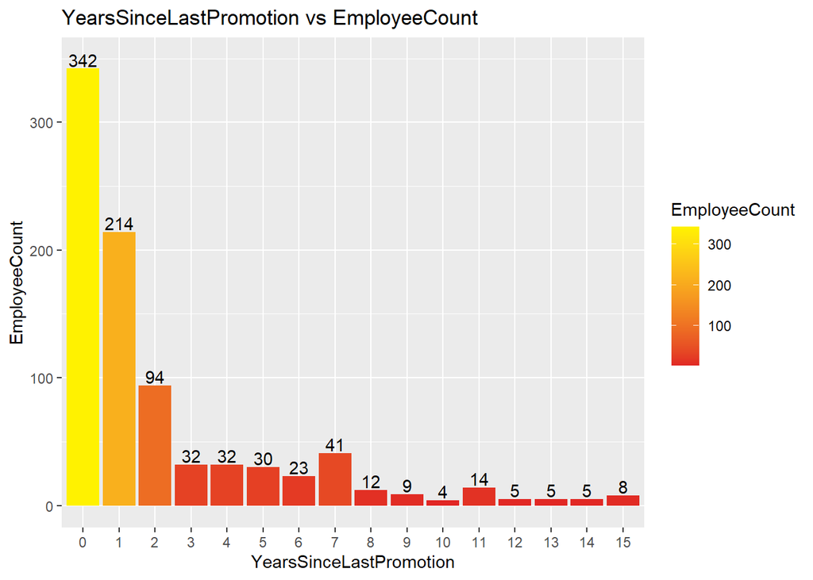

```r
ggplot(data=YearsSinceLastPromotiondf,aes(x=YearsSinceLastPromotion,y = EmployeeCount, fill = EmployeeCount ))+ geom_bar(stat ="identity")+ggtitle("YearsSinceLastPromotion vs EmployeeCount") + scale_fill_gradient2(low= '#971B1E', mid = '#E02124', high = '#FFF200', space='#E1E1E1')+ geom_text(aes(x= YearsSinceLastPromotion, EmployeeCount +7, label = EmployeeCount, fill = NULL), data = YearsSinceLastPromotiondf)
```

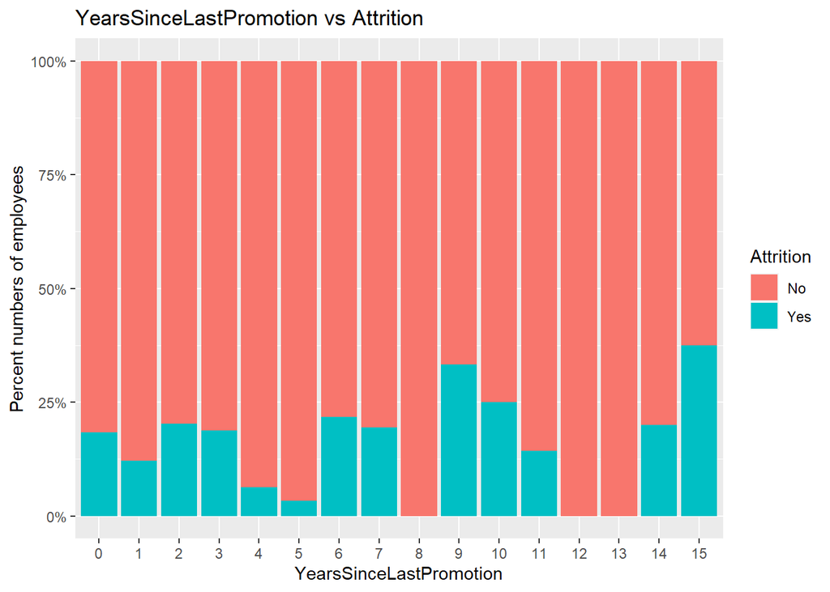

```r
ggplot(data, aes_string(x = "YearsSinceLastPromotion", fill = "Attrition")) +
  geom_bar(position = "fill") +
  scale_y_continuous(labels = scales::percent) +
  xlab("YearsSinceLastPromotion") + ylab("Percent numbers of employees") + ggtitle("YearsSinceLastPromotion vs Attrition")
```

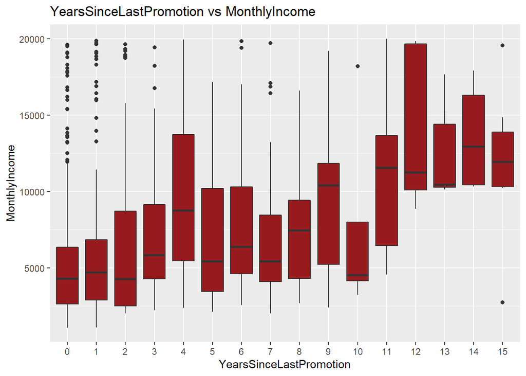

```r
ggplot(data,aes_string(x= "YearsSinceLastPromotion" , y ="MonthlyIncome", fill ="YearsSinceLastPromotion" ))+geom_boxplot(fill=c('#971B1E'))+ggtitle("YearsSinceLastPromotion vs MonthlyIncome")
```

###Years With Current Manager.most have o and 2 years with current manager. after 12,13 15 and 17 has low attrition. 14 years might be people just got promoted to managerial level.

```r
data$YearsWithCurrManager <- as.factor(data$YearsWithCurrManager)
YearsWithCurrManagerdf <-data %>% group_by(YearsWithCurrManager) %>% summarise(EmployeeCount =n(), Proportion = scales::percent(n()/dim(data)[1]))
YearsWithCurrManagerdf
```

```
## # A tibble: 17 x 3
##    YearsWithCurrManager EmployeeCount Proportion
##    <fct>                        <int> <chr>
##  1 0                              166 19%
##  2 1                               40 5%
##  3 2                              202 23%
##  4 3                               76 9%
##  5 4                               51 6%
##  6 5                               22 3%
##  7 6                               12 1%
##  8 7                              131 15%
##  9 8                               68 8%
## 10 9                               44 5%
## 11 10                              18 2%
## 12 11                              11 1%
## 13 12                              13 1%
## 14 13                               7 1%
## 15 14                               4 0%
## 16 15                               1 0%
## 17 17                               4 0%
```

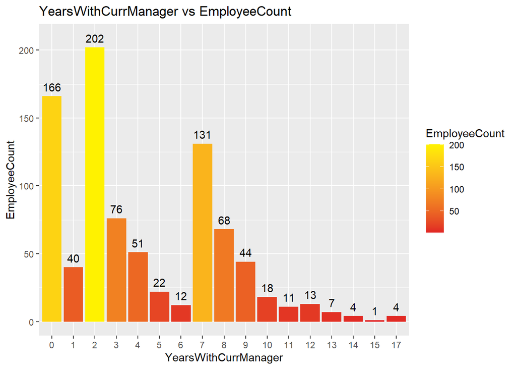

```r
ggplot(data=YearsWithCurrManagerdf,aes(x=YearsWithCurrManager,y = EmployeeCount, fill = EmployeeCount ))+ geom_bar(stat ="identity")+ggtitle("YearsWithCurrManager vs EmployeeCount") + scale_fill_gradient2(low= '#971B1E', mid = '#E02124', high = '#FFF200', space='#E1E1E1')+ geom_text(aes(x= YearsWithCurrManager, EmployeeCount +7, label = EmployeeCount, fill = NULL), data = YearsWithCurrManagerdf)
```

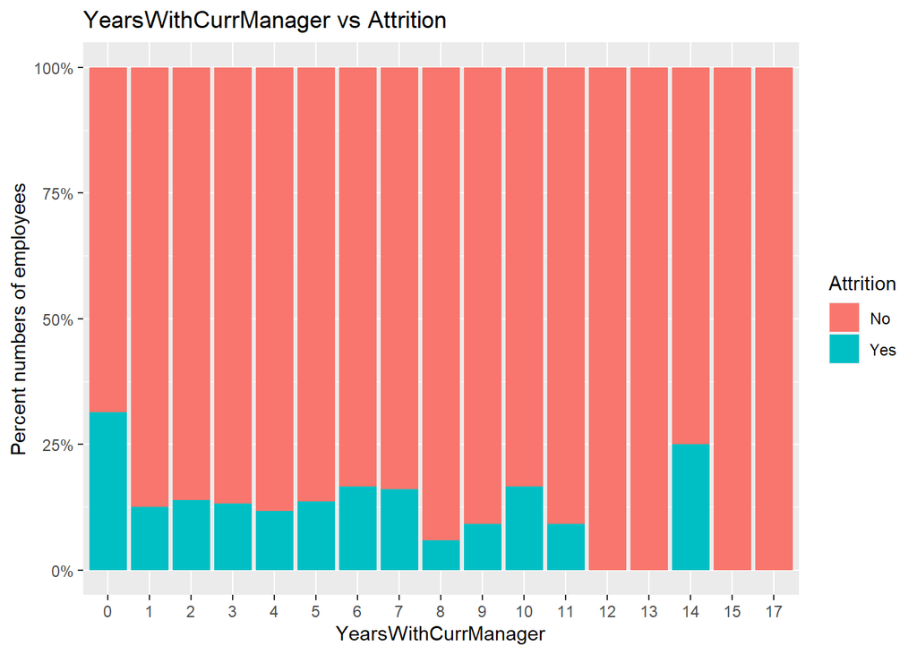

```r
ggplot(data, aes_string(x = "YearsWithCurrManager", fill = "Attrition")) +
  geom_bar(position = "fill") +
  scale_y_continuous(labels = scales::percent) +
   xlab("YearsWithCurrManager") + ylab("Percent numbers of employees") + ggtitle("YearsWithCurrManager vs Attrition")
```

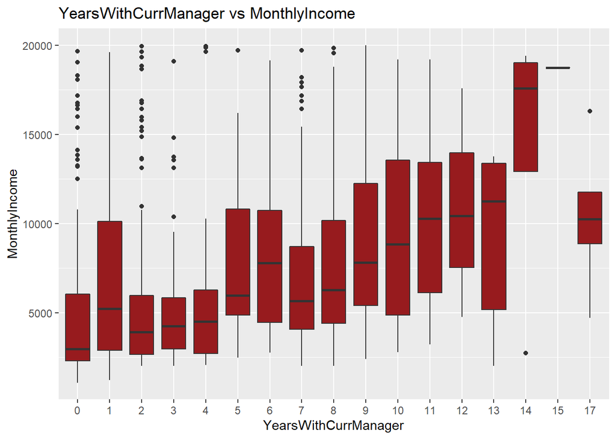

```r
ggplot(data,aes_string(x= "YearsWithCurrManager" , y ="MonthlyIncome", fill ="YearsWithCurrManager" ))+geom_boxplot(fill=c('#971B1E'))+ggtitle("YearsWithCurrManager vs MonthlyIncome")
```

### Finding correlations between Daily Rate, Hourly Rate,Monthly rate and Monthly Income. there is no correlation between these variables. SO I will create data fram without these variable but Monthly income.

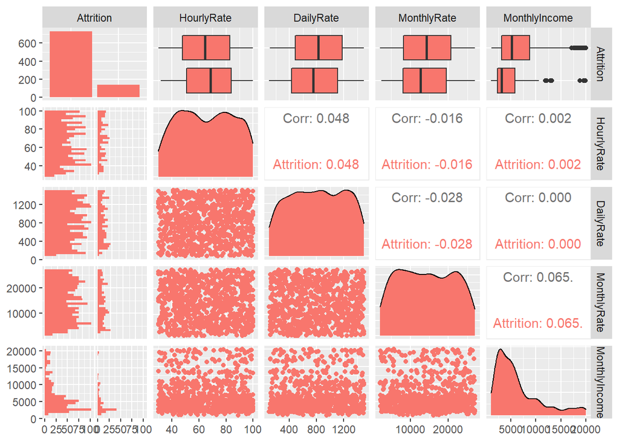

```r
data%>%select(Attrition,HourlyRate,DailyRate,MonthlyRate,MonthlyIncome)%>%ggpairs(aes(color= "Attrition"))
```

```r
data <- read.csv("CaseStudy2-data.csv",header = TRUE)
str(data)
```

```
## 'data.frame':    870 obs. of  36 variables:
##  $ ID                      : int  1 2 3 4 5 6 7 8 9 10 ...
##  $ Age                     : int  32 40 35 32 24 27 41 37 34 34 ...
##  $ Attrition               : chr  "No" "No" "No" "No" ...
##  $ BusinessTravel          : chr  "Travel_Rarely" "Travel_Rarely" "Travel_Frequently" "Travel_Rarely" ...
##  $ DailyRate               : int  117 1308 200 801 567 294 1283 309 1333 653 ...
##  $ Department              : chr  "Sales" "Research & Development" "Research & Development" "Sales" ...
##  $ DistanceFromHome        : int  13 14 18 1 2 10 5 10 10 10 ...
##  $ Education               : int  4 3 2 4 1 2 5 4 4 4 ...
##  $ EducationField          : chr  "Life Sciences" "Medical" "Life Sciences" "Marketing" ...
##  $ EmployeeCount           : int  1 1 1 1 1 1 1 1 1 1 ...
##  $ EmployeeNumber          : int  859 1128 1412 2016 1646 733 1448 1105 1055 1597 ...
##  $ EnvironmentSatisfaction : int  2 3 3 3 1 4 2 4 3 4 ...
##  $ Gender                  : chr  "Male" "Male" "Male" "Female" ...
##  $ HourlyRate              : int  73 44 60 48 32 32 90 88 87 92 ...
```

[output cut: 22 more lines]

```r
Newdata <- dplyr::select(data,-c("HourlyRate","DailyRate","MonthlyRate","ID","EmployeeNumber","Over18","EmployeeCount","StandardHours"))

str(Newdata)
```

```
## 'data.frame':    870 obs. of  28 variables:
##  $ Age                     : int  32 40 35 32 24 27 41 37 34 34 ...
##  $ Attrition               : chr  "No" "No" "No" "No" ...
##  $ BusinessTravel          : chr  "Travel_Rarely" "Travel_Rarely" "Travel_Frequently" "Travel_Rarely" ...
##  $ Department              : chr  "Sales" "Research & Development" "Research & Development" "Sales" ...
##  $ DistanceFromHome        : int  13 14 18 1 2 10 5 10 10 10 ...
##  $ Education               : int  4 3 2 4 1 2 5 4 4 4 ...
##  $ EducationField          : chr  "Life Sciences" "Medical" "Life Sciences" "Marketing" ...
##  $ EnvironmentSatisfaction : int  2 3 3 3 1 4 2 4 3 4 ...
##  $ Gender                  : chr  "Male" "Male" "Male" "Female" ...
##  $ JobInvolvement          : int  3 2 3 3 3 3 4 2 3 2 ...
##  $ JobLevel                : int  2 5 3 3 1 3 1 2 1 2 ...
##  $ JobRole                 : chr  "Sales Executive" "Research Director" "Manufacturing Director" "Sales Executive" ...
##  $ JobSatisfaction         : int  4 3 4 4 4 1 3 4 3 3 ...
##  $ MaritalStatus           : chr  "Divorced" "Single" "Single" "Married" ...
##  $ MonthlyIncome           : int  4403 19626 9362 10422 3760 8793 2127 6694 2220 5063 ...
##  $ NumCompaniesWorked      : int  2 1 2 1 1 1 2 2 1 1 ...
##  $ OverTime                : chr  "No" "No" "No" "No" ...
##  $ PercentSalaryHike       : int  11 14 11 19 13 21 12 14 19 14 ...
##  $ PerformanceRating       : int  3 3 3 3 3 4 3 3 3 3 ...
##  $ RelationshipSatisfaction: int  3 1 3 3 3 3 1 3 4 2 ...
##  $ StockOptionLevel        : int  1 0 0 2 0 2 0 3 1 1 ...
##  $ TotalWorkingYears       : int  8 21 10 14 6 9 7 8 1 8 ...
##  $ TrainingTimesLastYear   : int  3 2 2 3 2 4 5 5 2 3 ...
##  $ WorkLifeBalance         : int  2 4 3 3 3 2 2 3 3 2 ...
##  $ YearsAtCompany          : int  5 20 2 14 6 9 4 1 1 8 ...
##  $ YearsInCurrentRole      : int  2 7 2 10 3 7 2 0 1 2 ...
##  $ YearsSinceLastPromotion : int  0 4 2 5 1 1 0 0 0 7 ...
##  $ YearsWithCurrManager    : int  3 9 2 7 3 7 3 0 0 7 ...
```

```r
###converting intergers that needed to be factor
Newdata$EnvironmentSatisfaction <-as.numeric(Newdata$EnvironmentSatisfaction)
Newdata$JobInvolvement <- factor(Newdata$JobInvolvement)
Newdata$JobLevel <- as.numeric(Newdata$JobLevel)
Newdata$JobSatisfaction <- factor(Newdata$JobSatisfaction)
Newdata$PerformanceRating <- factor(Newdata$PerformanceRating)
Newdata$RelationshipSatisfaction <- factor(Newdata$RelationshipSatisfaction)
Newdata$WorkLifeBalance <- factor(Newdata$WorkLifeBalance)
Newdata$StockOptionLevel <- as.numeric(Newdata$StockOptionLevel)

##classifying factors and categorical variable.names
###[,Newdata] <- lapply(data[,Newdata],as.numeric)
cat <- Newdata%>% select_if(is.factor)
con <- Newdata%>% select_if(is.numeric)
```

### Creating the correlations plots between each continous/numeric variables. Monthly income has better correlation with other numeric variables

```r
str(con)
```

```
## 'data.frame':    870 obs. of  15 variables:
##  $ Age                    : int  32 40 35 32 24 27 41 37 34 34 ...
##  $ DistanceFromHome       : int  13 14 18 1 2 10 5 10 10 10 ...
##  $ Education              : int  4 3 2 4 1 2 5 4 4 4 ...
##  $ EnvironmentSatisfaction: num  2 3 3 3 1 4 2 4 3 4 ...
##  $ JobLevel               : num  2 5 3 3 1 3 1 2 1 2 ...
##  $ MonthlyIncome          : int  4403 19626 9362 10422 3760 8793 2127 6694 2220 5063 ...
##  $ NumCompaniesWorked     : int  2 1 2 1 1 1 2 2 1 1 ...
##  $ PercentSalaryHike      : int  11 14 11 19 13 21 12 14 19 14 ...
##  $ StockOptionLevel       : num  1 0 0 2 0 2 0 3 1 1 ...
##  $ TotalWorkingYears      : int  8 21 10 14 6 9 7 8 1 8 ...
##  $ TrainingTimesLastYear  : int  3 2 2 3 2 4 5 5 2 3 ...
##  $ YearsAtCompany         : int  5 20 2 14 6 9 4 1 1 8 ...
##  $ YearsInCurrentRole     : int  2 7 2 10 3 7 2 0 1 2 ...
##  $ YearsSinceLastPromotion: int  0 4 2 5 1 1 0 0 0 7 ...
##  $ YearsWithCurrManager   : int  3 9 2 7 3 7 3 0 0 7 ...
```

```r
library(corrplot)
con.cor <- cor(con)
print(con.cor)
```

```
##                                  Age DistanceFromHome   Education
## Age                      1.000000000      0.006647112  0.21729021
## DistanceFromHome         0.006647112      1.000000000  0.04951294
## Education                0.217290207      0.049512940  1.00000000
## EnvironmentSatisfaction -0.007449882     -0.038700752 -0.03652790
## JobLevel                 0.479423564      0.021727054  0.13038591
## MonthlyIncome            0.484288301     -0.006667155  0.12713139
## NumCompaniesWorked       0.293521877     -0.048909244  0.16091801
## PercentSalaryHike       -0.030804192      0.054293690 -0.00238712
## StockOptionLevel         0.044759576      0.071680428  0.03070687
## TotalWorkingYears        0.652613137      0.004186191  0.14604454
## TrainingTimesLastYear   -0.045281792     -0.038949194 -0.06313480
## YearsAtCompany           0.289538716     -0.020830094  0.06197449
## YearsInCurrentRole       0.208349696     -0.008407782  0.06138162
## YearsSinceLastPromotion  0.217191680     -0.016595666  0.06832997
## YearsWithCurrManager     0.185383795     -0.017700612  0.08844628
##                         EnvironmentSatisfaction      JobLevel MonthlyIncome
## Age                               -0.0074498822  0.4794235642   0.484288301
## DistanceFromHome                  -0.0387007522  0.0217270544  -0.006667155
## Education                         -0.0365278976  0.1303859075   0.127131394
## EnvironmentSatisfaction            1.0000000000  0.0001545152  -0.016877439
## JobLevel                           0.0001545152  1.0000000000   0.951640049
## MonthlyIncome                     -0.0168774388  0.9516400488   1.000000000
## NumCompaniesWorked                 0.0129457502  0.1408348284   0.155894318
## PercentSalaryHike                  0.0011391589 -0.0622671489  -0.053865939
## StockOptionLevel                   0.0302830223  0.0188872312   0.018888722
## TotalWorkingYears                 -0.0199565304  0.7807523526   0.778511205
## TrainingTimesLastYear             -0.0145019244 -0.0458643163  -0.039014567
## YearsAtCompany                    -0.0151005446  0.5205835070   0.491378966
## YearsInCurrentRole                 0.0224902874  0.3913048192   0.361840521
## YearsSinceLastPromotion            0.0091768217  0.3304357051   0.315911576
## YearsWithCurrManager              -0.0232922981  0.3665674724   0.328487453
##                         NumCompaniesWorked PercentSalaryHike StockOptionLevel
## Age                             0.29352188      -0.030804192      0.044759576
## DistanceFromHome               -0.04890924       0.054293690      0.071680428
## Education                       0.16091801      -0.002387120      0.030706874
## EnvironmentSatisfaction         0.01294575       0.001139159      0.030283022
## JobLevel                        0.14083483      -0.062267149      0.018887231
## MonthlyIncome                   0.15589432      -0.053865939      0.018888722
## NumCompaniesWorked              1.00000000      -0.022434259      0.032887211
```

[output cut: 41 more lines]

```
## Age                              0.185383795
## DistanceFromHome                -0.017700612
## Education                        0.088446276
## EnvironmentSatisfaction         -0.023292298
## JobLevel                         0.366567472
## MonthlyIncome                    0.328487453
## NumCompaniesWorked              -0.122974681
## PercentSalaryHike               -0.045232326
## StockOptionLevel                 0.036542574
## TotalWorkingYears                0.461485375
## TrainingTimesLastYear            0.003914247
## YearsAtCompany                   0.765226243
## YearsInCurrentRole               0.709461217
## YearsSinceLastPromotion          0.508935431
## YearsWithCurrManager             1.000000000
```

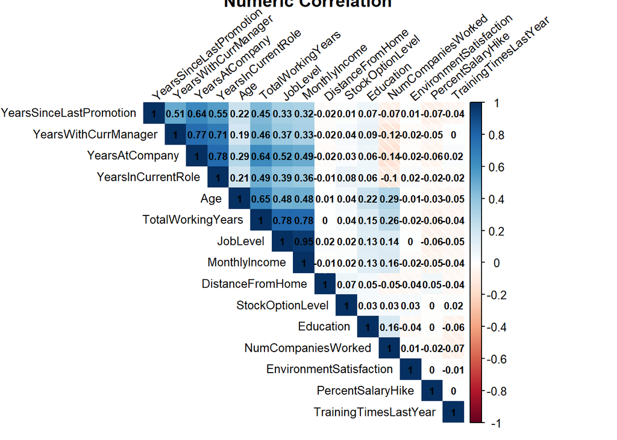

```r
corrplot(con.cor,type = "upper",order = "hclust",addCoef.col = "black",number.digits = 2,method = "shade",tl.srt=40, tl.cex = 0.8,tl.col = "black", number.cex = 0.7
         , title = "Numeric Correlation")
```

```r
set.seed(100)
data2 <- dplyr::select(Newdata,"MonthlyIncome", "Age", "Attrition", "BusinessTravel", "Department", "Education", "JobLevel", "JobRole", "NumCompaniesWorked", "TotalWorkingYears", "YearsAtCompany", "YearsInCurrentRole", "YearsSinceLastPromotion", "YearsWithCurrManager","StockOptionLevel")
head(data2)
```

```
##   MonthlyIncome Age Attrition    BusinessTravel             Department
## 1          4403  32        No     Travel_Rarely                  Sales
## 2         19626  40        No     Travel_Rarely Research & Development
## 3          9362  35        No Travel_Frequently Research & Development
## 4         10422  32        No     Travel_Rarely                  Sales
## 5          3760  24        No Travel_Frequently Research & Development
## 6          8793  27        No Travel_Frequently Research & Development
##   Education JobLevel                JobRole NumCompaniesWorked
## 1         4        2        Sales Executive                  2
## 2         3        5      Research Director                  1
## 3         2        3 Manufacturing Director                  2
## 4         4        3        Sales Executive                  1
## 5         1        1     Research Scientist                  1
## 6         2        3 Manufacturing Director                  1
##   TotalWorkingYears YearsAtCompany YearsInCurrentRole YearsSinceLastPromotion
## 1                 8              5                  2                       0
## 2                21             20                  7                       4
## 3                10              2                  2                       2
## 4                14             14                 10                       5
## 5                 6              6                  3                       1
## 6                 9              9                  7                       1
##   YearsWithCurrManager StockOptionLevel
## 1                    3                1
## 2                    9                0
## 3                    2                0
## 4                    7                2
## 5                    3                0
## 6                    7                2
```

```r
splitPerc1 = 0.8
trainIndices1 = sample(1:dim(data2)[1],round(splitPerc1 * dim(data2)[1]))
train1 = data2[trainIndices1,]
test1 = data2[-trainIndices1,]
lm1 = lm(MonthlyIncome ~ ., data = train1)
summary(lm1)
```

```
##
## Call:
## lm(formula = MonthlyIncome ~ ., data = train1)
##
## Residuals:
##     Min      1Q  Median      3Q     Max
## -3600.1  -623.7   -31.2   586.9  3939.2
##
## Coefficients:
##                                  Estimate Std. Error t value Pr(>|t|)
## (Intercept)                      -491.140    586.915  -0.837 0.402994
## Age                                -1.773      6.321  -0.281 0.779159
## AttritionYes                      115.382    118.402   0.974 0.330161
## BusinessTravelTravel_Frequently   193.143    158.077   1.222 0.222202
## BusinessTravelTravel_Rarely       412.513    135.683   3.040 0.002456 **
## DepartmentResearch & Development  231.807    474.864   0.488 0.625600
## DepartmentSales                  -353.857    482.219  -0.734 0.463321
## Education                         -29.763     41.436  -0.718 0.472825
## JobLevel                         2792.996     93.548  29.856  < 2e-16 ***
## JobRoleHuman Resources            -21.942    559.097  -0.039 0.968706
## JobRoleLaboratory Technician     -674.904    191.427  -3.526 0.000451 ***
## JobRoleManager                   4332.504    306.084  14.155  < 2e-16 ***
## JobRoleManufacturing Director     184.678    192.767   0.958 0.338390
## JobRoleResearch Director         4125.638    247.286  16.684  < 2e-16 ***
## JobRoleResearch Scientist        -354.902    192.714  -1.842 0.065973 .
## JobRoleSales Executive            577.889    391.732   1.475 0.140624
## JobRoleSales Representative       106.127    431.676   0.246 0.805874
## NumCompaniesWorked                 -4.186     18.899  -0.221 0.824772
## TotalWorkingYears                  49.404     12.172   4.059 5.51e-05 ***
## YearsAtCompany                      2.196     15.225   0.144 0.885361
## YearsInCurrentRole                 -1.578     18.565  -0.085 0.932275
## YearsSinceLastPromotion            30.916     17.300   1.787 0.074377 .
## YearsWithCurrManager              -45.276     18.824  -2.405 0.016432 *
## StockOptionLevel                   31.352     48.028   0.653 0.514111
## ---
## Signif. codes:  0 '***' 0.001 '**' 0.01 '*' 0.05 '.' 0.1 ' ' 1
##
## Residual standard error: 1067 on 672 degrees of freedom
## Multiple R-squared:  0.9492, Adjusted R-squared:  0.9475
## F-statistic: 546.1 on 23 and 672 DF,  p-value: < 2.2e-16
```

```r
pred1 = predict(lm1, test1)
RMSE = sqrt(mean((test1$MonthlyIncome - pred1)^2))
RMSE
```

```
## [1] 1034.676
```

### Competition set No salary. predicted with significant variables in salary.

```r
Nosalary <-readxl::read_xlsx("CaseStudy2CompSetNoSalary.xlsx")
```

```r
Nosalary1 <-dplyr::select(Nosalary, "Age", "Attrition", "BusinessTravel", "Department", "Education", "JobLevel", "JobRole", "NumCompaniesWorked", "TotalWorkingYears", "YearsAtCompany", "YearsInCurrentRole", "YearsSinceLastPromotion", "YearsWithCurrManager","StockOptionLevel")

lm2 = lm(MonthlyIncome ~ .,data = data2)
summary(lm2)
```

```
##
## Call:
## lm(formula = MonthlyIncome ~ ., data = data2)
##
## Residuals:
##     Min      1Q  Median      3Q     Max
## -3712.1  -620.3   -17.3   599.4  3965.2
##
## Coefficients:
##                                   Estimate Std. Error t value Pr(>|t|)
## (Intercept)                      -425.6564   532.2733  -0.800 0.424112
## Age                                -0.5890     5.5745  -0.106 0.915871
## AttritionYes                       40.2184   104.4728   0.385 0.700360
## BusinessTravelTravel_Frequently   199.7585   139.5672   1.431 0.152722
## BusinessTravelTravel_Rarely       394.9823   118.2031   3.342 0.000870 ***
## DepartmentResearch & Development  148.3483   438.3822   0.338 0.735146
## DepartmentSales                  -382.8372   445.2626  -0.860 0.390142
## Education                         -32.6407    36.7432  -0.888 0.374607
## JobLevel                         2788.4915    82.3708  33.853  < 2e-16 ***
## JobRoleHuman Resources           -222.0532   510.7457  -0.435 0.663846
## JobRoleLaboratory Technician     -614.0837   168.9460  -3.635 0.000295 ***
## JobRoleManager                   4213.9502   279.4032  15.082  < 2e-16 ***
## JobRoleManufacturing Director     139.7069   167.9111   0.832 0.405627
## JobRoleResearch Director         4020.9400   216.7822  18.548  < 2e-16 ***
## JobRoleResearch Scientist        -344.6623   169.1657  -2.037 0.041918 *
## JobRoleSales Executive            480.2893   356.1026   1.349 0.177782
## JobRoleSales Representative        71.8209   389.9542   0.184 0.853918
## NumCompaniesWorked                  8.0345    16.6435   0.483 0.629405
## TotalWorkingYears                  48.5571    10.9046   4.453 9.61e-06 ***
## YearsAtCompany                     -0.5032    13.3582  -0.038 0.969960
## YearsInCurrentRole                  1.9267    16.7287   0.115 0.908336
## YearsSinceLastPromotion            27.9464    15.1174   1.849 0.064861 .
## YearsWithCurrManager              -26.6152    16.5288  -1.610 0.107721
## StockOptionLevel                    6.6758    42.5343   0.157 0.875320
## ---
## Signif. codes:  0 '***' 0.001 '**' 0.01 '*' 0.05 '.' 0.1 ' ' 1
##
## Residual standard error: 1056 on 846 degrees of freedom
## Multiple R-squared:  0.9486, Adjusted R-squared:  0.9472
## F-statistic: 679.2 on 23 and 846 DF,  p-value: < 2.2e-16
```

```r
pred2 =predict(lm2,Nosalary1)
MonthlyIncome = pred2
pred2 = as.data.frame(MonthlyIncome)

comsetwithsalary = cbind(pred2,Nosalary1)

### this csv file will be submitted to GitHub.
write.csv(comsetwithsalary,"Case2PredictionsKarkiSalary.csv",row.names = TRUE)
```

###Naive Bayes classifier

```r
library(e1071)
data3 <- select(data,"Attrition", "Age", "Department",  "EnvironmentSatisfaction",  "JobInvolvement",  "JobLevel", "JobRole",  "JobSatisfaction", "MaritalStatus",  "MonthlyIncome", "NumCompaniesWorked",  "OverTime", "StockOptionLevel",  "TotalWorkingYears", "WorkLifeBalance", "YearsAtCompany", "YearsInCurrentRole", "YearsWithCurrManager")
str(data3)
```

```
## 'data.frame':    870 obs. of  18 variables:
##  $ Attrition              : chr  "No" "No" "No" "No" ...
##  $ Age                    : int  32 40 35 32 24 27 41 37 34 34 ...
##  $ Department             : chr  "Sales" "Research & Development" "Research & Development" "Sales" ...
##  $ EnvironmentSatisfaction: int  2 3 3 3 1 4 2 4 3 4 ...
##  $ JobInvolvement         : int  3 2 3 3 3 3 4 2 3 2 ...
##  $ JobLevel               : int  2 5 3 3 1 3 1 2 1 2 ...
##  $ JobRole                : chr  "Sales Executive" "Research Director" "Manufacturing Director" "Sales Executive" ...
##  $ JobSatisfaction        : int  4 3 4 4 4 1 3 4 3 3 ...
##  $ MaritalStatus          : chr  "Divorced" "Single" "Single" "Married" ...
##  $ MonthlyIncome          : int  4403 19626 9362 10422 3760 8793 2127 6694 2220 5063 ...
##  $ NumCompaniesWorked     : int  2 1 2 1 1 1 2 2 1 1 ...
##  $ OverTime               : chr  "No" "No" "No" "No" ...
##  $ StockOptionLevel       : int  1 0 0 2 0 2 0 3 1 1 ...
##  $ TotalWorkingYears      : int  8 21 10 14 6 9 7 8 1 8 ...
##  $ WorkLifeBalance        : int  2 4 3 3 3 2 2 3 3 2 ...
##  $ YearsAtCompany         : int  5 20 2 14 6 9 4 1 1 8 ...
##  $ YearsInCurrentRole     : int  2 7 2 10 3 7 2 0 1 2 ...
##  $ YearsWithCurrManager   : int  3 9 2 7 3 7 3 0 0 7 ...
```

```r
data3$Attrition<-as.factor(data$Attrition)
set.seed(1000)
splitPerc2 = 0.8
trainIndices2 = sample(1:dim(data3)[1],round(splitPerc1 * dim(data3)[1]))
train2 = data3[trainIndices2,]
test2 = data3[-trainIndices2,]
Naive_Bayes<- naiveBayes(Attrition~.,data = train2,laplace = -1)
predNB = predict(Naive_Bayes, test2)

##str(data3)
table((test2$Attrition),predNB)
```

```
##      predNB
##        No Yes
##   No  127  21
##   Yes  10  16
```

```r
Con.Mat = confusionMatrix(predNB,test2$Attrition)
Con.Mat
```

```
## Confusion Matrix and Statistics
##
##           Reference
## Prediction  No Yes
##        No  127  10
##        Yes  21  16
##
##                Accuracy : 0.8218
##                  95% CI : (0.7568, 0.8756)
##     No Information Rate : 0.8506
##     P-Value [Acc > NIR] : 0.87743
##
##                   Kappa : 0.4032
##
##  Mcnemar's Test P-Value : 0.07249
##
##             Sensitivity : 0.8581
##             Specificity : 0.6154
##          Pos Pred Value : 0.9270
##          Neg Pred Value : 0.4324
##              Prevalence : 0.8506
##          Detection Rate : 0.7299
##    Detection Prevalence : 0.7874
##       Balanced Accuracy : 0.7367
##
##        'Positive' Class : No
##
```

###since Naive base is 85 % sensitive and 62 % specific. I used this model to predict competition set with no attrition. ##Per Question- model has to be atleast 60 % sensitive and 60 % specific

```r
Noattrition <- read.csv("CaseStudy2CompSet No Attrition.csv",header = TRUE)
str(Noattrition)
```

```
## 'data.frame':    300 obs. of  35 variables:
##  $ ID                      : int  1171 1172 1173 1174 1175 1176 1177 1178 1179 1180 ...
##  $ Age                     : int  35 33 26 55 29 51 52 39 31 31 ...
##  $ BusinessTravel          : chr  "Travel_Rarely" "Travel_Rarely" "Travel_Rarely" "Travel_Rarely" ...
##  $ DailyRate               : int  750 147 1330 1311 1246 1456 585 1387 1062 534 ...
##  $ Department              : chr  "Research & Development" "Human Resources" "Research & Development" "Research & Development" ...
##  $ DistanceFromHome        : int  28 2 21 2 19 1 29 10 24 20 ...
##  $ Education               : int  3 3 3 3 3 4 4 5 3 3 ...
##  $ EducationField          : chr  "Life Sciences" "Human Resources" "Medical" "Life Sciences" ...
##  $ EmployeeCount           : int  1 1 1 1 1 1 1 1 1 1 ...
##  $ EmployeeNumber          : int  1596 1207 1107 505 1497 145 2019 1618 1252 587 ...
##  $ EnvironmentSatisfaction : int  2 2 1 3 3 1 1 2 3 1 ...
##  $ Gender                  : chr  "Male" "Male" "Male" "Female" ...
##  $ HourlyRate              : int  46 99 37 97 77 30 40 76 96 66 ...
##  $ JobInvolvement          : int  4 3 3 3 2 2 3 3 2 3 ...
```

[output cut: 21 more lines]

```r
Noattrition1 <- select(Noattrition,"Age", "Department",  "EnvironmentSatisfaction",  "JobInvolvement",  "JobLevel", "JobRole",  "JobSatisfaction", "MaritalStatus",  "MonthlyIncome", "NumCompaniesWorked",  "OverTime", "StockOptionLevel",  "TotalWorkingYears", "WorkLifeBalance", "YearsAtCompany", "YearsInCurrentRole", "YearsWithCurrManager")

NaiveBayes2 <- naiveBayes(Attrition ~., data = data3, laplace = -1)
pred3 =predict(NaiveBayes2,Noattrition1)
Attrition = pred3
Attrition = as.data.frame(Attrition)



comsetwithattrition = cbind(Noattrition1,Attrition)

write.csv(comsetwithattrition,"Case2PredictionsKarkiAttrition.csv",row.names = FALSE)
```

##Analyzing top 3

```r
str(Newdata)
```

```
## 'data.frame':    870 obs. of  28 variables:
##  $ Age                     : int  32 40 35 32 24 27 41 37 34 34 ...
##  $ Attrition               : chr  "No" "No" "No" "No" ...
##  $ BusinessTravel          : chr  "Travel_Rarely" "Travel_Rarely" "Travel_Frequently" "Travel_Rarely" ...
##  $ Department              : chr  "Sales" "Research & Development" "Research & Development" "Sales" ...
##  $ DistanceFromHome        : int  13 14 18 1 2 10 5 10 10 10 ...
##  $ Education               : int  4 3 2 4 1 2 5 4 4 4 ...
##  $ EducationField          : chr  "Life Sciences" "Medical" "Life Sciences" "Marketing" ...
##  $ EnvironmentSatisfaction : num  2 3 3 3 1 4 2 4 3 4 ...
##  $ Gender                  : chr  "Male" "Male" "Male" "Female" ...
##  $ JobInvolvement          : Factor w/ 4 levels "1","2","3","4": 3 2 3 3 3 3 4 2 3 2 ...
##  $ JobLevel                : num  2 5 3 3 1 3 1 2 1 2 ...
##  $ JobRole                 : chr  "Sales Executive" "Research Director" "Manufacturing Director" "Sales Executive" ...
##  $ JobSatisfaction         : Factor w/ 4 levels "1","2","3","4": 4 3 4 4 4 1 3 4 3 3 ...
##  $ MaritalStatus           : chr  "Divorced" "Single" "Single" "Married" ...
##  $ MonthlyIncome           : int  4403 19626 9362 10422 3760 8793 2127 6694 2220 5063 ...
##  $ NumCompaniesWorked      : int  2 1 2 1 1 1 2 2 1 1 ...
##  $ OverTime                : chr  "No" "No" "No" "No" ...
##  $ PercentSalaryHike       : int  11 14 11 19 13 21 12 14 19 14 ...
##  $ PerformanceRating       : Factor w/ 2 levels "3","4": 1 1 1 1 1 2 1 1 1 1 ...
##  $ RelationshipSatisfaction: Factor w/ 4 levels "1","2","3","4": 3 1 3 3 3 3 1 3 4 2 ...
##  $ StockOptionLevel        : num  1 0 0 2 0 2 0 3 1 1 ...
##  $ TotalWorkingYears       : int  8 21 10 14 6 9 7 8 1 8 ...
##  $ TrainingTimesLastYear   : int  3 2 2 3 2 4 5 5 2 3 ...
##  $ WorkLifeBalance         : Factor w/ 4 levels "1","2","3","4": 2 4 3 3 3 2 2 3 3 2 ...
##  $ YearsAtCompany          : int  5 20 2 14 6 9 4 1 1 8 ...
##  $ YearsInCurrentRole      : int  2 7 2 10 3 7 2 0 1 2 ...
##  $ YearsSinceLastPromotion : int  0 4 2 5 1 1 0 0 0 7 ...
##  $ YearsWithCurrManager    : int  3 9 2 7 3 7 3 0 0 7 ...
```

```r
Newdata$Attrition <- as.factor(Newdata$Attrition)
top3<- earth(Attrition ~., data = Newdata)
I <- evimp(top3)
I[1:3,c(3,4,6)]
```

```
##                      nsubsets       gcv       rss
## OverTimeYes                29 100.00000 100.00000
## YearsWithCurrManager       28  85.87430  89.14158
## StockOptionLevel           27  78.25733  83.15568
```

```r
data <- read.csv("CaseStudy2-data.csv",header = TRUE)
Newdata2 <- select(data,-c("HourlyRate","DailyRate","MonthlyRate","ID","EmployeeNumber","Over18","EmployeeCount","StandardHours"))


Newdata2$Attrition[Newdata2$Attrition =="Yes"]=1
Newdata2$Attrition[Newdata2$Attrition =="No"]= 0
Newdata2$Attrition = as.numeric(Newdata2$Attrition)

str(Newdata2)
```

```
## 'data.frame':    870 obs. of  28 variables:
##  $ Age                     : int  32 40 35 32 24 27 41 37 34 34 ...
##  $ Attrition               : num  0 0 0 0 0 0 0 0 0 0 ...
##  $ BusinessTravel          : chr  "Travel_Rarely" "Travel_Rarely" "Travel_Frequently" "Travel_Rarely" ...
##  $ Department              : chr  "Sales" "Research & Development" "Research & Development" "Sales" ...
##  $ DistanceFromHome        : int  13 14 18 1 2 10 5 10 10 10 ...
##  $ Education               : int  4 3 2 4 1 2 5 4 4 4 ...
##  $ EducationField          : chr  "Life Sciences" "Medical" "Life Sciences" "Marketing" ...
##  $ EnvironmentSatisfaction : int  2 3 3 3 1 4 2 4 3 4 ...
##  $ Gender                  : chr  "Male" "Male" "Male" "Female" ...
##  $ JobInvolvement          : int  3 2 3 3 3 3 4 2 3 2 ...
##  $ JobLevel                : int  2 5 3 3 1 3 1 2 1 2 ...
##  $ JobRole                 : chr  "Sales Executive" "Research Director" "Manufacturing Director" "Sales Executive" ...
##  $ JobSatisfaction         : int  4 3 4 4 4 1 3 4 3 3 ...
##  $ MaritalStatus           : chr  "Divorced" "Single" "Single" "Married" ...
##  $ MonthlyIncome           : int  4403 19626 9362 10422 3760 8793 2127 6694 2220 5063 ...
##  $ NumCompaniesWorked      : int  2 1 2 1 1 1 2 2 1 1 ...
##  $ OverTime                : chr  "No" "No" "No" "No" ...
##  $ PercentSalaryHike       : int  11 14 11 19 13 21 12 14 19 14 ...
##  $ PerformanceRating       : int  3 3 3 3 3 4 3 3 3 3 ...
##  $ RelationshipSatisfaction: int  3 1 3 3 3 3 1 3 4 2 ...
##  $ StockOptionLevel        : int  1 0 0 2 0 2 0 3 1 1 ...
##  $ TotalWorkingYears       : int  8 21 10 14 6 9 7 8 1 8 ...
##  $ TrainingTimesLastYear   : int  3 2 2 3 2 4 5 5 2 3 ...
##  $ WorkLifeBalance         : int  2 4 3 3 3 2 2 3 3 2 ...
##  $ YearsAtCompany          : int  5 20 2 14 6 9 4 1 1 8 ...
##  $ YearsInCurrentRole      : int  2 7 2 10 3 7 2 0 1 2 ...
##  $ YearsSinceLastPromotion : int  0 4 2 5 1 1 0 0 0 7 ...
##  $ YearsWithCurrManager    : int  3 9 2 7 3 7 3 0 0 7 ...
```

```r
dataknn <- select(Newdata2,"Attrition", "Age",  "EnvironmentSatisfaction",  "JobInvolvement",  "JobLevel",  "JobSatisfaction",  "MonthlyIncome", "NumCompaniesWorked", "StockOptionLevel",  "TotalWorkingYears", "WorkLifeBalance", "YearsAtCompany", "YearsInCurrentRole", "YearsWithCurrManager")
str(dataknn)
```

```
## 'data.frame':    870 obs. of  14 variables:
##  $ Attrition              : num  0 0 0 0 0 0 0 0 0 0 ...
##  $ Age                    : int  32 40 35 32 24 27 41 37 34 34 ...
##  $ EnvironmentSatisfaction: int  2 3 3 3 1 4 2 4 3 4 ...
##  $ JobInvolvement         : int  3 2 3 3 3 3 4 2 3 2 ...
##  $ JobLevel               : int  2 5 3 3 1 3 1 2 1 2 ...
##  $ JobSatisfaction        : int  4 3 4 4 4 1 3 4 3 3 ...
##  $ MonthlyIncome          : int  4403 19626 9362 10422 3760 8793 2127 6694 2220 5063 ...
##  $ NumCompaniesWorked     : int  2 1 2 1 1 1 2 2 1 1 ...
##  $ StockOptionLevel       : int  1 0 0 2 0 2 0 3 1 1 ...
##  $ TotalWorkingYears      : int  8 21 10 14 6 9 7 8 1 8 ...
##  $ WorkLifeBalance        : int  2 4 3 3 3 2 2 3 3 2 ...
##  $ YearsAtCompany         : int  5 20 2 14 6 9 4 1 1 8 ...
##  $ YearsInCurrentRole     : int  2 7 2 10 3 7 2 0 1 2 ...
##  $ YearsWithCurrManager   : int  3 9 2 7 3 7 3 0 0 7 ...
```

```r
set.seed(100)
splitPerc2 = 0.8
trainIndices3 = sample(1:dim(dataknn)[1],round(splitPerc1 * dim(dataknn)[1]))
train3= dataknn[trainIndices3,]
test3 = dataknn[-trainIndices3,]
classifications = knn(train3,test3,train3$Attrition, prob = TRUE, k = 10)
  table(classifications,test3$Attrition)
```

```
##
## classifications   0   1
##               0 146  26
##               1   1   1
```

```r
  CM = confusionMatrix(table(classifications,test3$Attrition))

CM
```

```
## Confusion Matrix and Statistics
##
##
## classifications   0   1
##               0 146  26
##               1   1   1
##
##                Accuracy : 0.8448
##                  95% CI : (0.7823, 0.8952)
##     No Information Rate : 0.8448
##     P-Value [Acc > NIR] : 0.5511
##
##                   Kappa : 0.0486
##
##  Mcnemar's Test P-Value : 3.86e-06
##
##             Sensitivity : 0.99320
##             Specificity : 0.03704
##          Pos Pred Value : 0.84884
##          Neg Pred Value : 0.50000
##              Prevalence : 0.84483
##          Detection Rate : 0.83908
##    Detection Prevalence : 0.98851
##       Balanced Accuracy : 0.51512
##
##        'Positive' Class : 0
##
```